# Validación Cruzada

Pedro José Piqueras Martínez

25/2/2023

# 0) Introducción.

La estadística es una rama de las matemáticas que se encarga de recolectar, analizar e interpretar datos. Una de las principales aplicaciones de la estadística es el modelado de fenómenos y la predicción de resultados futuros.

Podemos entender el análisis de datos como el procedimiento mediante el cual utilizamos herramientas informáticas junto a técnicas estadísticas para convertir los datos en información la cual analizar y sacar conclusiones útiles para la toma de decisiones.

El objetivo de este proyecto es encontrar el mejor modelo para el conjunto de datos de credit score utilizando técnicas de entrenamiento y validación cruzada, es decir, aquel que tenga el mejor rendimiento en términos de precisión y generalización. Buscamos un modelo con la mayor sensibilidad, es decir la mejor capacidad para predecir los casos negativos en los que no se concede el crédito.

La metodología del código busca ser estructurado, eficiente, reproducible y completo. Estructurado en tanto que está en distintos script, para así facilitar la división del trabajo, poder reutilizar los script por separado y evitar que se arrastren fallos de una tarea a otra. Eficiente tanto computacionalmente como en el número de líneas que se van a escribir. La reproducibilidad se enfoca en tener un código bien comentado y también preparado para reutilizarse con el mínimo de cambios posibles. Completo en el sentido de que vamos a usar todos los modelos y técnicas posibles. Esto último puede entrar en conflicto con la reproducibilidad, por ello solo se seleccionan para ser ejecutados algunos modelos y técnicas.

En lo referente a la metodología de este documento, resaltar que en todo momento se borran las variables instrumentales por motivos de eficiencia, pero esto queda oculto.

# 1) Preparación y descripción.

## 1.1 Carga y preparación de los datos

En esta parte del trabajo se cargan los datos de un archivo de Excel, se analizan y convierten en factores las variables categóricas para su posterior análisis. Así mismo, se renombran las variables para que el informe se pueda reproducir con mayor facilidad.

En el siguiente código cargamos los datos y los mostramos. La función `read_excel` carga los datos,`datatable` nos los muestra con un formato más visual y `str` nos dice el tipo de cada variable.

```r
# leemos excel
df <- read_excel("DATOS/credsco.xlsx")

# mostramos los datos
datatable(df,fillContainer=TRUE)
```

|  | Dictamen | Ant.trabajo | Vivienda | Plazo | Edad | Estado.civil | Tipo.trabajo | Gastos | Ingresos | Patrimonio | Cargas.patrimoniales | Importe.solicitado | Precio.del.bien.financiado |
| --- | --- | --- | --- | --- | --- | --- | --- | --- | --- | --- | --- | --- | --- |
| 1 | negativo | 0 | padres | 48 | 41 | casado | temporal | 900 | 800 | 0 | 0 | 12000 | 14680 |
| 2 | negativo | 0 | otros | 18 | 21 | soltero | temporal | 350 | 500 | 0 | 0 | 4000 | 5000 |
| 3 | negativo | 0 | ignora contrato | 48 | 36 | casado | temporal | 450 | 1300 | 7500 | 0 | 11000 | 15110 |
| 4 | negativo | 1 | escritura publica | 60 | 45 | casado | temporal | 1050 | 1120 | 20000 | 5000 | 6000 | 13320 |
| 5 | negativo | 0 | escritura publica | 36 | 23 | soltero | temporal | 450 | 1220 | 25000 | 0 | 4000 | 4000 |
| 6 | negativo | 2 | escritura publica | 60 | 43 | casado | temporal | 750 | 710 | 30000 | 0 | 15000 | 15520 |
| 7 | negativo | 0 | alquiler | 60 | 25 | soltero | temporal | 400 | 500 | 0 | 0 | 10400 | 10480 |
| 8 | negativo | 0 | alquiler | 36 | 29 | casado | temporal | 780 | 1800 | 0 | 0 | 6500 | 6500 |
| 9 | negativo | 1 | alquiler | 36 | 24 | casado | temporal | 760 | 1640 | 0 | 0 | 9000 | 9500 |
| 10 | negativo | 1 | escritura publica | 60 | 27 | casado | temporal | 750 | 1600 | 40000 | 30000 | 18000 | 21000 |

[output cut: 3934 more lines]

```r
# tipos de variables
str(df)
```

```
## tibble [3,944 × 13] (S3: tbl_df/tbl/data.frame)
##  $ Dictamen                  : chr [1:3944] "negativo" "negativo" "negativo" "negativo" ...
##  $ Ant.trabajo               : num [1:3944] 0 0 0 1 0 2 0 0 1 1 ...
##  $ Vivienda                  : chr [1:3944] "padres" "otros" "ignora contrato" "escritura publica" ...
##  $ Plazo                     : num [1:3944] 48 18 48 60 36 60 60 36 36 60 ...
##  $ Edad                      : num [1:3944] 41 21 36 45 23 43 25 29 24 27 ...
##  $ Estado.civil              : chr [1:3944] "casado" "soltero" "casado" "casado" ...
##  $ Tipo.trabajo              : chr [1:3944] "temporal" "temporal" "temporal" "temporal" ...
##  $ Gastos                    : num [1:3944] 900 350 450 1050 450 750 400 780 760 750 ...
##  $ Ingresos                  : num [1:3944] 800 500 1300 1120 1220 710 500 1800 1640 1600 ...
##  $ Patrimonio                : num [1:3944] 0 0 7500 20000 25000 30000 0 0 0 40000 ...
##  $ Cargas.patrimoniales      : num [1:3944] 0 0 0 5000 0 0 0 0 0 30000 ...
##  $ Importe.solicitado        : num [1:3944] 12000 4000 11000 6000 4000 15000 10400 6500 9000 18000 ...
##  $ Precio.del.bien.financiado: num [1:3944] 14680 5000 15110 13320 4000 ...
```

Algunas variables aparecen como `chr` cuando en realidad son factores, por tanto, las convertimos a factor usando `mutate_if` y `as.factor`.

```r
df <- df |> mutate_if(is.character, as.factor)
```

Usando nuestra función `NOMBRE_VARIABLES` renombramos nuestras variables para facilitar la reproducibilidad del trabajo y evitar problemas ortográficos. Creamos una tabla llamada `nombres_df` para poder identificar las variables.

```r
# creamos nuevos nombres y guardamos los viejos
nombres_df <- colnames(df)

colnames(df) <- NOMBRE_VARIABLES(dim(df)[2])

nombres_df <- data.frame('Original'= nombres_df,
                         'Nuevo'=NOMBRE_VARIABLES(dim(df)[2]))

# mostramos los nuevos nombres
datatable(nombres_df)
```

|  | Original | Nuevo |
| --- | --- | --- |
| 1 | Dictamen | X_1 |
| 2 | Ant.trabajo | X_2 |
| 3 | Vivienda | X_3 |
| 4 | Plazo | X_4 |
| 5 | Edad | X_5 |
| 6 | Estado.civil | X_6 |
| 7 | Tipo.trabajo | X_7 |
| 8 | Gastos | X_8 |
| 9 | Ingresos | X_9 |
| 10 | Patrimonio | X_10 |

[output cut: 3 more lines]

Creamos una clave primaria que nos servirá posteriormente para recuperar los outliers

```r
# creamos una clave primaria
df$ID <- paste0("ID_", 1:nrow(df))
```

## 1.2 Valores ausentes

En este apartado vamos a identificar posibles valores ausentes y operar los datos para evitar problemas con ellos.

```r
# Recuento de NA (FALSE)
datatable(data.frame(table(complete.cases(df))))
```

|  | Var1 | Freq |
| --- | --- | --- |
| 1 | FALSE | 4 |
| 2 | TRUE | 3940 |

```r
# Observaciones con NA
datatable(df[!complete.cases(df),],fillContainer = TRUE)
```

|  | X_1 | X_2 | X_3 | X_4 | X_5 | X_6 | X_7 | X_8 | X_9 | X_10 | X_11 | X_12 | X_13 | ID |
| --- | --- | --- | --- | --- | --- | --- | --- | --- | --- | --- | --- | --- | --- | --- |
| 1 |  | 2 | alquiler | 36 | 21 | soltero | fijo | 450 | 1000 | 0 | 0 | 7000 | 8250 | ID_3941 |
| 2 |  | 4 | padres | 24 | 27 | soltero | fijo | 350 | 1100 | 0 | 0 | 3700 | 5250 | ID_3942 |
| 3 |  | 6 | alquiler | 48 | 65 | casado | otros | 690 | 2370 | 0 | 0 | 15710 | 15710 | ID_3943 |
| 4 |  | 13 | escritura publica | 60 | 34 | separado | fijo | 350 | 560 | 70000 | 15000 | 12500 | 15250 | ID_3944 |

```r
# NA por observacion
head(rowSums(is.na(df)))
```

```
## [1] 0 0 0 0 0 0
```

```r
# Observaciones con NA
which(is.na(df))
```

```
## [1] 3941 3942 3943 3944
```

```r
# NA por variable
colSums(is.na(df))
```

```
##  X_1  X_2  X_3  X_4  X_5  X_6  X_7  X_8  X_9 X_10 X_11 X_12 X_13   ID
##    4    0    0    0    0    0    0    0    0    0    0    0    0    0
```

Identificamos que existen cuatro observaciones con NA en la variable objetivo `X_1`, son observaciones que queremos predecir y las separamos a la tabla `nd`.

```r
nd <- df[which(is.na(df)),]
df <- df[-which(is.na(df)),]
```

## 1.3 Análisis descriptivo.

En este apartado vamos a estudiar nuestros datos para tratar de obtener una visión general y entender su distribución y relaciones. Se trata de un análisis descriptivo y no de diagnóstico, por tanto, no aspiramos a explicar el por qué.

### 1.3.1 Medidas y relaciones

En este apartado emplearemos medidas de resumen de la distribución y las relaciones. Nuestra función `RESUMEN` nos ofrece los principales estadísticos para nuestras variables.

Esto puede hacerse con otras funciones como `summary` o `skimr`.

Observamos que las variables tienen una escala dispar, lo cual solucionaremos posteriormente. Además no parecen pertenecer a una normal, por la diferencia entre su media y mediana así como por su asimetría y curtosis. Otra cuestión relevante es que hay máximos y mínimos muy alejados de los cuartiles, lo que sumado a la diferencia entre media y mediana es indicador de la presencia de outliers.

```r
# resumen estadístico
datatable(RESUMEN(df),fillContainer=TRUE)
```

|  | variable | media | varianza | sd | cv | min | q1 | mediana | q3 | max | dq | asimetria | curtosis |
| --- | --- | --- | --- | --- | --- | --- | --- | --- | --- | --- | --- | --- | --- |
| 1 | X_2 | 8.94035532994924 | 70.5227173146834 | 8.39778049931549 | 0.939311715182484 | 0 | 2 | 6 | 14 | 47 | 12 | 1.205222652903 | 4.22299800125154 |
| 2 | X_4 | 46.3279187817259 | 220.03968746738 | 14.8337347781124 | 0.320189966831913 | 6 | 36 | 48 | 60 | 60 | 24 | -0.781617564899331 | 2.57558223328901 |
| 3 | X_5 | 37.5210659898477 | 122.267390587165 | 11.0574585953177 | 0.294700011942879 | 18 | 28 | 36 | 46 | 68 | 18 | 0.486181725881784 | 2.35900194233734 |
| 4 | X_8 | 570.875634517766 | 38360.0099164544 | 195.857116073056 | 0.34308193278997 | 350 | 440 | 590 | 750 | 1730 | 310 | 0.872592954009432 | 3.92786692703314 |
| 5 | X_9 | 1501.0076142132 | 726252.068995068 | 852.204241361816 | 0.567754775720126 | 60 | 990 | 1300 | 1800 | 9590 | 810 | 2.63947647129614 | 16.0021720888934 |
| 6 | X_10 | 53847.5812182741 | 10537525502.5258 | 102652.450056128 | 1.90635210967082 | 0 | 0 | 35000 | 60000 | 2000000 | 60000 | 8.11424973612078 | 109.048246055841 |
| 7 | X_11 | 3425.30203045685 | 126614041.416751 | 11252.2904964612 | 3.28505060178896 | 0 | 0 | 0 | 0 | 214000 | 0 | 6.9773886330916 | 88.0946168697034 |
| 8 | X_12 | 10012.3350253807 | 19357328.2858001 | 4399.69638563845 | 0.43942760349963 | 1000 | 7000 | 10000 | 12500 | 38750 | 5500 | 0.862119498327265 | 5.65916464702526 |
| 9 | X_13 | 14449.078680203 | 36106962.2634194 | 6008.90691086319 | 0.415867824091519 | 1250 | 11257.5 | 13860 | 16632.5 | 111400 | 5375 | 3.42777523398612 | 38.0866530951196 |

Calculamos las proporción de las clases de nuestra variable objetivo. Están desequilibradas, lo cual puede hacer imprecisos a los clasificadores por clase.

```r
# calculamos probabilidades a priori
p_priori <- df %>% group_by(X_1) %>%
    summarise('n_observaciones'=n()) %>%
    mutate('p_priori'=n_observaciones/sum(n_observaciones)) %>%
    data.frame()

# mostramos
datatable(p_priori,fillContainer=TRUE)
```

|  | X_1 | n_observaciones | p_priori |
| --- | --- | --- | --- |
| 1 | negativo | 500 | 0.126903553299492 |
| 2 | positivo | 3440 | 0.873096446700508 |

Mediante las matrices de covarianzas y correlaciones podemos tratar de entender las relaciones entre las variables.

```r
# matriz varianzas - covarianzas
covarianzas <- df |> select(where(is.numeric)) |> cov() |> round(3)
datatable(covarianzas, fillContainer=TRUE)
```

|  | X_2 | X_4 | X_5 | X_8 | X_9 | X_10 | X_11 | X_12 | X_13 |
| --- | --- | --- | --- | --- | --- | --- | --- | --- | --- |
| X_2 | 70.523 | -2.319 | 48.913 | 226.061 | 789.875 | 122353.181 | -2409.026 | 678.118 | 2249.379 |
| X_4 | -2.319 | 220.04 | -13.342 | -75.23 | -596.883 | -141375.927 | 10908.563 | 28916.868 | 9024.613 |
| X_5 | 48.913 | -13.342 | 122.267 | 529.605 | 1425.134 | 257532.883 | -7294.505 | 267.455 | 1288.848 |
| X_8 | 226.061 | -75.23 | 529.605 | 38360.01 | 47791.527 | 911504.149 | 65367.481 | 37983.916 | 50206.849 |
| X_9 | 789.875 | -596.883 | 1425.134 | 47791.527 | 726252.069 | 22129157.35 | 1620380.693 | 850028.035 | 1228623.447 |
| X_10 | 122353.181 | -141375.927 | 257532.883 | 911504.149 | 22129157.35 | 10537525502.526 | 168033307.877 | 91562022.735 | 176934158.726 |
| X_11 | -2409.026 | 10908.563 | -7294.505 | 65367.481 | 1620380.693 | 168033307.877 | 126614041.417 | 2614607.088 | 3154190.288 |
| X_12 | 678.118 | 28916.868 | 267.455 | 37983.916 | 850028.035 | 91562022.735 | 2614607.088 | 19357328.286 | 17791471.51 |
| X_13 | 2249.379 | 9024.613 | 1288.848 | 50206.849 | 1228623.447 | 176934158.726 | 3154190.288 | 17791471.51 | 36106962.263 |

```r
# matriz correlaciones
correlaciones <- df |> select(where(is.numeric)) |> cor() |> round(3)
datatable(correlaciones,fillContainer=TRUE)
```

|  | X_2 | X_4 | X_5 | X_8 | X_9 | X_10 | X_11 | X_12 | X_13 |
| --- | --- | --- | --- | --- | --- | --- | --- | --- | --- |
| X_2 | 1 | -0.019 | 0.527 | 0.137 | 0.11 | 0.142 | -0.025 | 0.018 | 0.045 |
| X_4 | -0.019 | 1 | -0.081 | -0.026 | -0.047 | -0.093 | 0.065 | 0.443 | 0.101 |
| X_5 | 0.527 | -0.081 | 1 | 0.245 | 0.151 | 0.227 | -0.059 | 0.005 | 0.019 |
| X_8 | 0.137 | -0.026 | 0.245 | 1 | 0.286 | 0.045 | 0.03 | 0.044 | 0.043 |
| X_9 | 0.11 | -0.047 | 0.151 | 0.286 | 1 | 0.253 | 0.169 | 0.227 | 0.24 |
| X_10 | 0.142 | -0.093 | 0.227 | 0.045 | 0.253 | 1 | 0.145 | 0.203 | 0.287 |
| X_11 | -0.025 | 0.065 | -0.059 | 0.03 | 0.169 | 0.145 | 1 | 0.053 | 0.047 |
| X_12 | 0.018 | 0.443 | 0.005 | 0.044 | 0.227 | 0.203 | 0.053 | 1 | 0.673 |
| X_13 | 0.045 | 0.101 | 0.019 | 0.043 | 0.24 | 0.287 | 0.047 | 0.673 | 1 |

### 1.3.2 Análisis gráfico.

Mediante el uso de visualizaciones podemos complementar las medidas y lograr una mejor comprensión de nuestros datos.

El siguiente código crea un histograma y gráfico de densidad para cada una de nuestras variables:

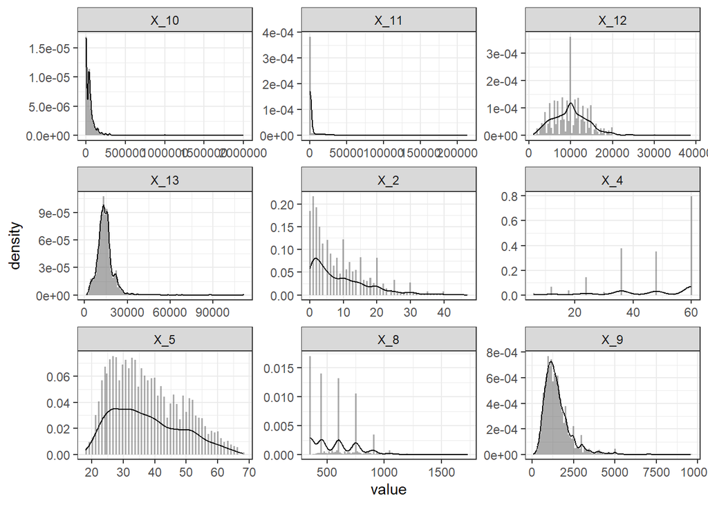

```r
ggplot(gather(df |> select(where(is.numeric)), variable, value), aes(x = value)) +
  geom_histogram(aes(y = after_stat(density)),
                 alpha = 0.5, position = "identity",bins=100) + # histogrmas
  geom_density(alpha = 0.5) + # densidad teorica
  facet_wrap(~ variable, scales = "free")+
  theme_bw() # tema
```

Podemos estudiar cuales se comportan de forma más o menos normal. Colas largas podrían indicar outliers, las distribuciones multimodales pueden indicar grupos.

Los gráficos de caja y bigotes muestran información sobre la distribución pero de forma simplificada y fácil de analizar. Los puntos fuera de los bigotes (rango intercuantílico) son potenciales outliers.

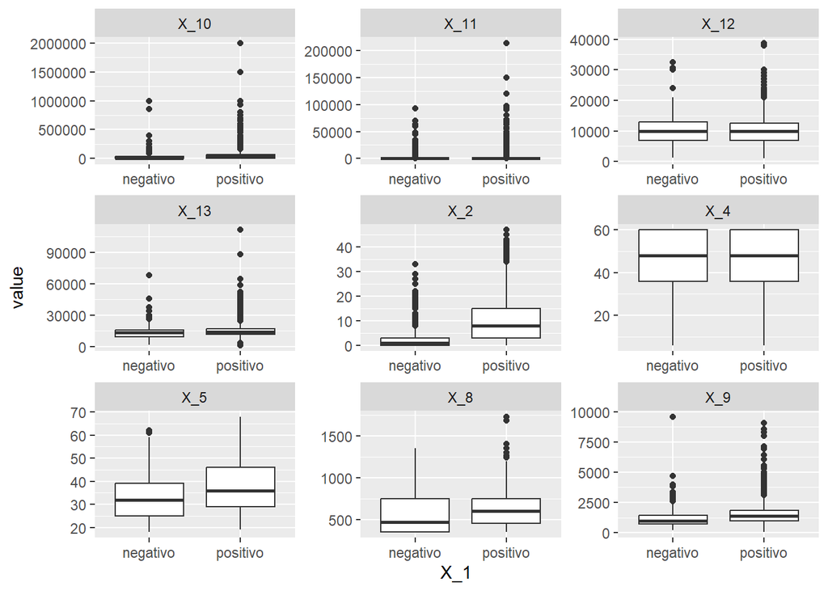

```r
ggplot(gather(df |> select(where(is.numeric),X_1),
              variable, value,-X_1), aes(x = X_1, y = value)) +
  geom_boxplot() +
  facet_wrap(~ variable, scales = "free")
```

Una versión más completa de estos son los llamados gráficos de violin, que además, muestran la densidad:

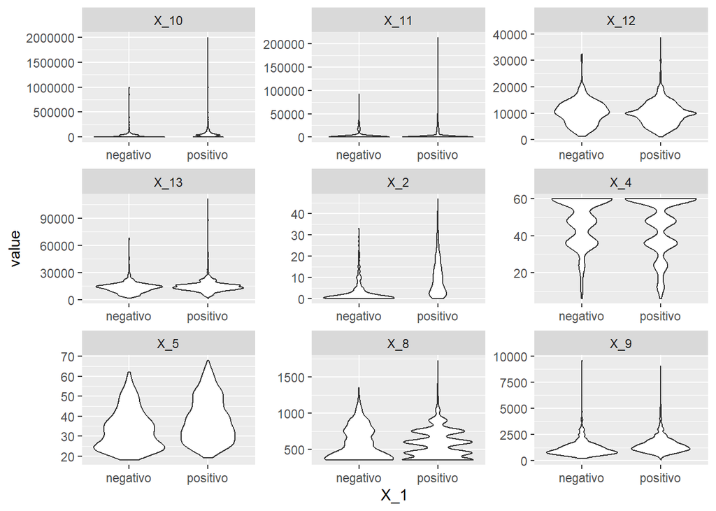

```r
ggplot(gather(df |> select(where(is.numeric),X_1),
              variable, value,-X_1), aes(x = X_1, y = value)) +
  geom_violin() +
  facet_wrap(~ variable, scales = "free")
```

También podemos ver de forma gráfica las correlaciones entre variables:

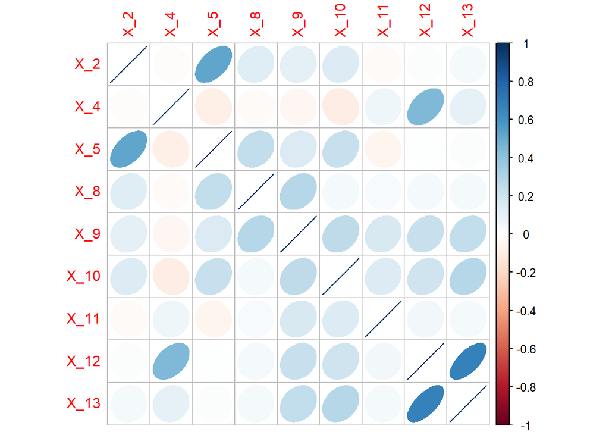

```r
corrplot(correlaciones,'ellipse')
```

## 1.4 Homogenización.

Nuestras variables presentan una escala muy diferente, lo cual puede perjudicar la precisión de los clasificadores, sobre todo aquellos basados en distancias, así como la detección de outliers. Además, una similar escala facilita comparaciones.

El método que vamos a utilizar es tipificar nuestros datos, de forma que quedan con media 0 y varianza 1. Pero hay otras alternativas como tomar logaritmos o normalizar.

```r
#df_original <- df # si queremos guardar datos originales

#nd_original <- nd # si queremos guardar datos originales

df <- df %>%
  select_if(is.numeric) %>% # seleccionamos numericas
  scale() %>% # tipificamos
  as.data.frame() %>% # convertimos en data frame
  cbind(df %>% select_if(function(x) !is.numeric(x))) %>% # unimos no numericas
  select(X_1,everything()) # X_1 primera columna

nd <- nd %>%
  select_if(is.numeric) %>% # seleccionamos numericas
  scale() %>% # tipificamos
  as.data.frame() %>% # convertimos en data frame
  cbind(nd %>% select_if(function(x) !is.numeric(x))) %>% # unimos no numericas
  select(X_1,everything()) # X_1 primera columna
```

# 2) Detección de Anomalías.

El objetivo de este apartado es emplear distintas técnicas para detectar posibles outliers. Esto es importante pues la presencia de estos datos anómalos puede perjudicar la estimación de estadísticos, lo que nos puede llevar a una menor precisión.

En primer lugar realizamos unos pasos previos; guardar los datos originales y retirar `X_11` que provoca problemas en algunas técnicas.

```r
# quitamos variables que den problemas
df <- df %>% select(-X_11)

# creamos data frame con los datos originales
df_original <- df
```

## 2.1 Métodos gráficos.

Vamos a realizar un análisis de componentes principales (PCA) para tratar de representar nuestros datos en 2 dimensiones mediante un biplot:

```r
# analisis de componentes principales (PCA)
pca <- prcomp(df %>% select(where(is.numeric)), scale = TRUE)

# informacion explicada
summary(pca)
```

```
## Importance of components:
##                           PC1    PC2    PC3    PC4    PC5     PC6    PC7
## Standard deviation     1.4742 1.3145 1.0521 1.0054 0.8168 0.79491 0.6687
## Proportion of Variance 0.2716 0.2160 0.1384 0.1263 0.0834 0.07898 0.0559
## Cumulative Proportion  0.2716 0.4876 0.6260 0.7524 0.8358 0.91475 0.9707
##                            PC8
## Standard deviation     0.48453
## Proportion of Variance 0.02935
## Cumulative Proportion  1.00000
```

```r
# porcentaje explicado por PC1 y PC2
summary(pca)[[6]][3,2] * 100
```

```
## [1] 48.764
```

El porcentaje de variabilidad explicada por los dos primeros componentes es muy reducida, aun así vamos a realizar el biplot con ánimo de practicar:

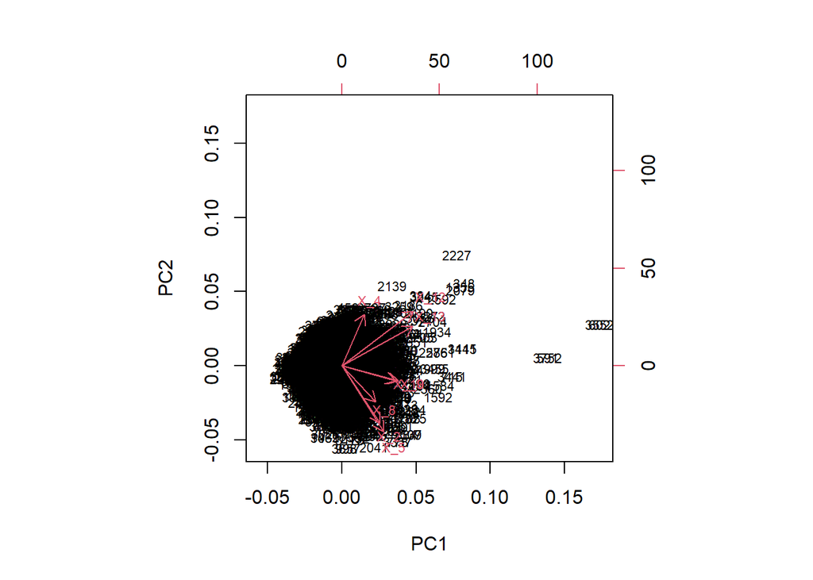

```r
# dibujamos biplot
biplot(pca, cex = 0.7)
```

Aquellos valores que toman valores muy elevados o combinaciones extrañas son potenciales outliers.

## 2.2 Métodos estadísticos.

En este apartado vamos a emplear métodos que trabajan mediante contrastes de hipótesis.

### 2.2.1 Método univariante de la distancia intercuartílica.

Este método para la detección de outliers univariantes se basa en ver que valores se alejan más de un múltiplo de veces sobre la distancia intercuartílica.

Mediante nuestra función `OUTLIERS_IQR` buscamos aquellas observaciones que se alejan por encima o por debajo más de 1.5 veces la distancia intercuartílica.

```r
# para una columna: coef=1.5
OUTLIERS_IQR(df,2,1.5)
```

```
##  [1]  367  515  526  576  665  718  728  729  861  876  936  947  998 1166 1236
## [16] 1327 1377 1450 1502 1521 1532 1566 1628 1715 1731 1829 1834 1866 1934 2041
## [31] 2065 2135 2152 2235 2258 2347 2390 2501 2583 2611 2679 2686 2729 2756 2797
## [46] 2842 2946 3032 3094 3121 3175 3199 3205 3217 3240 3283 3353 3416 3429 3502
## [61] 3601 3657 3686 3706 3788 3813 3886 3892
```

Hemos programado la función `OUTLIERS_IQR_TOTAL` que aplica a todas las columnas mediante un loop. La salida es una lista con tantos elementos como variables y que guardan los potenciales outliers univariantes para cada variable.

```r
# para todas las columnas: coef=1.5
outliers_iqr <- df %>%  OUTLIERS_IQR_TOTAL(1.5)
```

No aplicamos esta técnica para retirar outliers pues un potencial outlier univariante no tiene por qué serlo en una dimensión múltiple ya que puede pertenercer a una tendencia o correlación.

```r
# si quisieramos quitar otliers segun la variable 1 de la lista:
# df[-outliers_iqr[[1]],]

# si quisieramos quitar segun todas las variables:
# for(i in 1:length(outliers_iqr)){df <- df[-outliers_iqr[[i]],]}
```

Usando nuestra función `dist_mediana` podemos calcular la observación con mayor distancia absoluta a la mediana por variable:

```r
# observacion con mayor distancia a la mediana por variable

df %>% select_if(is.numeric) %>% dist_mediana() %>% datatable()
```

|  | Variable | Observacion | Distancia |
| --- | --- | --- | --- |
| X_2 | X_2 | 2729 | 4.88224239765995 |
| X_4 | X_4 | 145 | 2.8313840464488 |
| X_5 | X_5 | 513 | 2.89397420972939 |
| X_8 | X_8 | 741 | 5.82056972377136 |
| X_9 | X_9 | 352 | 9.72771502140454 |
| X_10 | X_10 | 591 | 19.1422610851041 |
| X_12 | X_12 | 2079 | 6.53454181380473 |
| X_13 | X_13 | 2227 | 16.2325696581624 |

### 2.2.2. Contrastes de normalidad.

Hay ténicas de detección de outliers, de clasificación y para equilibrar las probabilidades a priori que se basan en la asunción de una distribución normal. Por ello, vamos a tratar de contrastar esta asunción mediante el test de Shapiro-Wilks cuya hipótesis nula es la existencia de normalidad en una variable.

```r
# Saphiro Test

# Ho Normal

# para una variable

shapiro.test(df[,2])
```

```
##
##  Shapiro-Wilk normality test
##
## data:  df[, 2]
## W = 0.87988, p-value < 2.2e-16
```

```r
# para todas las variables por clase

df %>%
  group_by(X_1) %>%
  select(where(is.numeric)) %>%
  summarise_all(list(~ shapiro.test(.)$p.value)) %>%
  ungroup()
```

```
## # A tibble: 2 × 9
##   X_1         X_2      X_4      X_5      X_8      X_9     X_10     X_12     X_13
##   <fct>     <dbl>    <dbl>    <dbl>    <dbl>    <dbl>    <dbl>    <dbl>    <dbl>
## 1 negat… 1.33e-31 1.35e-23 4.51e-13 1.50e-19 3.75e-27 1.18e-39 4.48e- 9 5.08e-20
## 2 posit… 6.01e-43 4.06e-51 4.08e-29 6.05e-43 1.72e-53 5.79e-73 1.42e-30 1.88e-53
```

Contrastamos las variables por grupos porque la ausencia de normalidad puede deberse a la existencia de grupos que se reflejen en una distribución multimodal.

Advertencia: el test de Saphiro-Wilks en R 4.2.2 tiene como límite 5000 observaciones.

### 2.2.3 Contrastes para outliers univariantes.

El test de Grubbs es muy intuitivo pues se basa en el valor tipificado que más se aleja de la media.

Nuestra función `GRUBBS_TABLA` crea una tabla resumen con los resultados para cada variable.

```r
# Ho: No hay outliers
# H1: Hay un outlier

# para una variable
grubbs.test(df[,2])
```

```
##
##  Grubbs test for one outlier
##
## data:  df[, 2]
## G = 4.53211, U = 0.99478, p-value = 0.0112
## alternative hypothesis: highest value 4.5321075816584 is an outlier
```

```r
# creamos un data frame con los resultados
GRUBBS_TABLA(df,0.05)
```

```
##      variable      p_value    H0
## X_2       X_2 1.120116e-02 FALSE
## X_4       X_4 1.000000e+00  TRUE
## X_5       X_5 1.000000e+00  TRUE
## X_8       X_8 5.929374e-06 FALSE
## X_9       X_9 0.000000e+00 FALSE
## X_10     X_10 0.000000e+00 FALSE
## X_12     X_12 1.140191e-07 FALSE
## X_13     X_13 0.000000e+00 FALSE
```

```r
# para todas las variables por clase
df %>%
  group_by(X_1) %>%
  select(where(is.numeric)) %>%
  summarise_all(list(~ grubbs.test(.)$p.value)) %>%
  ungroup()
```

```
## # A tibble: 2 × 9
##   X_1               X_2   X_4   X_5        X_8   X_9  X_10         X_12  X_13
##   <fct>           <dbl> <dbl> <dbl>      <dbl> <dbl> <dbl>        <dbl> <dbl>
## 1 negativo 0.0000000177 0.192 0.836 0.0703         0     0 0.000134         0
## 2 positivo 0.0181       1     1     0.00000284     0     0 0.0000000802     0
```

Si quisieramos eliminar outliers con este método podríamos usar nuestra función `GRUBBS_REMOVER` que emplea `GRUBBS_TABLA` para ver que variables rechazan el test y entonces elimina la observación más valor el estadístico de Grubbs.

```r
# eliminar outliers segun test Grubbs una vez
# df = GRUBBS_REMOVER(df,0.05)
```

No lo haremos pues los métodos univariantes obvian las correlaciones y tendencias.

### 2.2.4 Distancia de Mahalanobis.

La distancia de Mahalanobis es un tipo de distancia que tiene en cuenta las correlaciones entre variables, de forma que si un valor está lejos del centroide por ser un valor extremo en una correlación, no tiene una distancia de Mahalanobis demasiado elevada. De forma visual serían elipses entorno al centroide, al contrario que la distancia euclídea donde son círculos.

La distancia de Mahalanobis asume la existencia de una distribución normal multivariante, por ello tenemos que contrastar si es cierto.

```r
mvn(df %>% select(where(is.numeric)), mvnTest = "hz")$multivariateNormality
```

```
##            Test       HZ p value MVN
## 1 Henze-Zirkler 13.56792       0  NO
```

La distancia de Mahalanobis se estima mediante la función `mahalanobis`

```r
maha.F <- df %>% select(where(is.numeric)) %>% # numericas
  mahalanobis(center = colMeans(.), cov = cov(.)) # centroide y varianzas
```

La distancia de Mahalanobis estándar se distribuye según una chi-cuadrado de p grados de libertad, siendo p el número de variables cuando los datos se distribuyen de forma normal. Dado que vamos a contrastar simultáneamente varias observaciones provocamos un FWER, por tanto, debemos corregir el nivel de significación.

`qchisq` calcula el valor que deja probabilidad a la izquierda, por tanto recibe como argumento 1-alfa.

```r
# numero de variables numericas
p <- df %>% select(where(is.numeric)) %>% ncol()

# n de outliers a detectar
n <- 150

# nivel de significacion
alfa <- 0.05

# limite para ser outlier
# chi-cuadrado con correccion de Sidak
(limite <- qchisq(p = 1-(1-(1-alfa)^(1/n)) , df = p))
```

```
## [1] 28.81352
```

Podemos analizar gráficamente las observaciones según su valor de distancia.

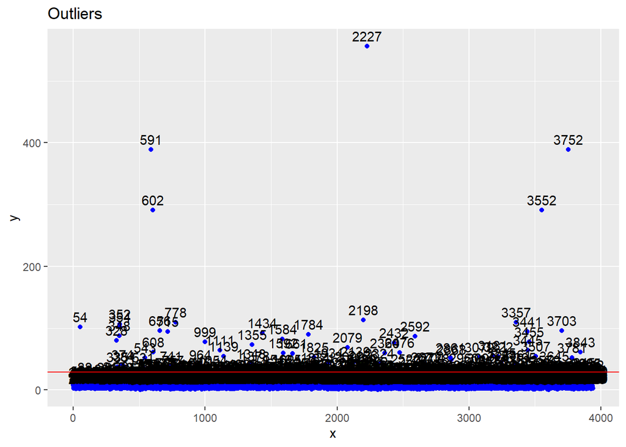

```r
# grafico distancia por observacion
ggplot(data.frame(x = 1:length(df[,1]), y = maha.F), aes(x = x, y = y)) +
  geom_point(pch = 16, col = "blue") +
  geom_text(aes(label = x),hjust = 0.5, vjust = -0.5, col = "black") +
  labs(title = "Outliers") +
  geom_hline(yintercept = limite, col = "red")
```

Podemos ver quines superan la distancia límite y cuántos son:

```r
# cuales superan el limite
which(maha.F>limite)
```

```
##  [1]   54  328  335  348  352  354  374  384  531  543  591  602  608  656  715
## [16]  741  757  778  964  999 1054 1111 1139 1348 1355 1378 1434 1546 1584 1592
## [31] 1615 1621 1661 1784 1825 1834 1871 1934 2071 2079 2092 2139 2180 2190 2196
## [46] 2198 2227 2272 2324 2360 2432 2476 2520 2575 2592 2673 2704 2738 2861 2868
## [61] 2960 3066 3079 3096 3175 3181 3186 3222 3245 3251 3352 3357 3361 3395 3441
## [76] 3445 3455 3507 3552 3579 3645 3703 3752 3781 3843
```

```r
# cuantas lo superan
length(which(maha.F>limite))
```

```
## [1] 85
```

Si quisieramos quitar outliers con esta técnica usariamos el siguiente código. Recordemos que empleamos una correción del nivel de significación para n outliers. Cómo mucho podemos quitar con criterio estadístico esos n.

No lo vamos a ejecutar pues emplearemos la distancia robusta.

```r
"
if(length(which(maha.F>limite))>n){ # mas outliers de n solo borramos n
  df <- df[-order(maha.F, decreasing = TRUE)[1:n],]
}else{ # menos outliers de n
  df <- df[-which(maha.F>limite) ,]
}
"
```

```
## [1] "\nif(length(which(maha.F>limite))>n){ # mas outliers de n solo borramos n\n  df <- df[-order(maha.F, decreasing = TRUE)[1:n],]\n}else{ # menos outliers de n\n  df <- df[-which(maha.F>limite) ,]\n}\n"
```

### 2.2.5 Distancia de Mahalanobis Robusta.

La distancia de Mahalanobis robusta funciona mejor ante la presencia de outliers y la ausencia de normalidad.

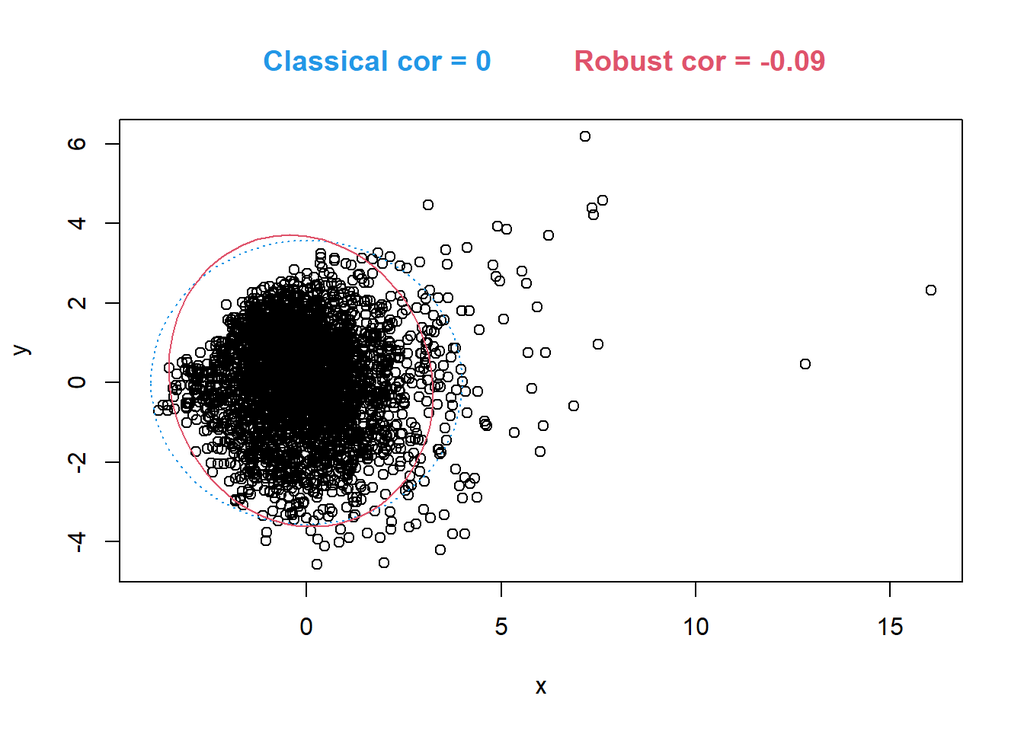

```
## $cor.cla
## [1] -9.018705e-16
##
## $cor.rob
## [1] -0.08588152
```

```r
# biplot estandar vs robusta
# puntuaciones PC1 y PC2
scores <- as.data.frame(pca$x[, 1:2])
# grafico
corr.plot(scores[, 1], scores[, 2])
```

La distancia de Mahalanobis robusta la estimamos utilizando el método del determinante mínimo de covarianza (MCD)

```r
# estimacion robusta
maha.F <- df %>% select(where(is.numeric)) %>%
  mahalanobis(center = covMcd(.)$center, # centroide
              cov = covMcd(.)$cov)       # varianzas
```

Típicamente la distribución de este estadístico es desconocida pero se puede aproximar mediante simulaciones o bootstrap. Por motivos de simplicidad, vamos a trabajar (erróneamente) con una chi-cuadrado de p grados de libertad como sucede con la distancia no robusta en caso de normalidad.

Dado que hacemos múltiples contrastes debemos corregir el nivel de significación para reducir el FWER.

`qchisq` calcula el valor que deja probabilidad a la izquierda, por tanto recibe como argumento 1-alfa.

```r
# numero de variables numericas
p <- df %>% select(where(is.numeric)) %>% ncol()

# n de outliers a detectar
n <- 150

# nivel de significacion
alfa <- 0.05

# limite para ser outlier
# chi-cuadrado con correccion de Sidak
(limite <- qchisq(p = 1-(1-(1-alfa)^(1/n)) , df = p))
```

```
## [1] 28.81352
```

Aunque los datos no sean normales, las observaciones con una distancia muy extrema son potencialmente outliers, el problema vendría en caso de distancia moderada.

Gráficamente:

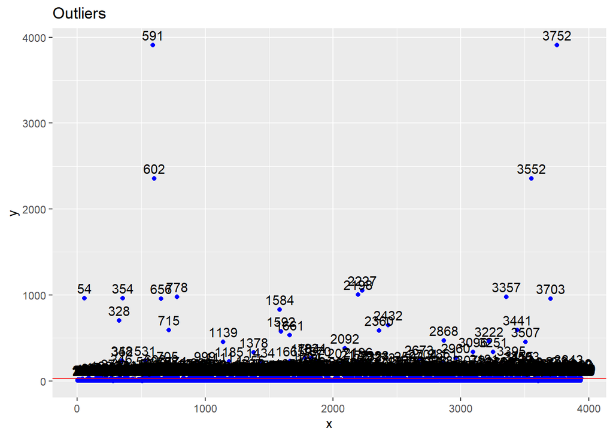

```r
# grafico distancia por observacion
ggplot(data.frame(x = 1:length(df[,1]), y = maha.F), aes(x = x, y = y)) +
  geom_point(pch = 16, col = "blue") +
  geom_text(aes(label = x),hjust = 0.5, vjust = -0.5, col = "black") +
  labs(title = "Outliers") +
  geom_hline(yintercept = limite, col = "red")
```

Podemos estudiar quiénes rebasan el límite y cuántos son:

```r
# cuales superan el limite
which(maha.F>limite)
```

```
##   [1]   54   88  151  188  222  265  271  328  335  346  348  352  354  369  374
##  [16]  384  390  391  514  531  532  543  556  559  560  570  571  572  574  576
##  [31]  590  591  596  602  603  608  614  627  656  683  697  705  707  708  715
##  [46]  724  727  733  741  757  774  778  782  788  825  873  878  883  887  894
##  [61]  905  914  919  933  955  963  964  968  980  988  998  999 1011 1024 1038
##  [76] 1041 1052 1054 1059 1061 1110 1111 1139 1145 1149 1157 1185 1200 1207 1251
##  [91] 1253 1262 1277 1285 1307 1308 1326 1337 1348 1355 1356 1378 1380 1385 1393
## [106] 1429 1434 1437 1461 1465 1467 1468 1479 1504 1506 1515 1537 1542 1546 1559
## [121] 1567 1584 1585 1592 1594 1599 1606 1615 1621 1639 1651 1653 1661 1665 1693
## [136] 1724 1728 1738 1746 1762 1773 1780 1783 1784 1785 1794 1811 1817 1824 1825
## [151] 1826 1833 1834 1850 1857 1863 1870 1871 1874 1896 1902 1934 1945 1968 1995
## [166] 2013 2014 2016 2027 2041 2071 2079 2086 2092 2102 2106 2114 2120 2131 2139
## [181] 2147 2152 2168 2173 2180 2184 2189 2190 2196 2198 2210 2212 2218 2227 2243
## [196] 2252 2253 2272 2300 2319 2320 2323 2324 2337 2347 2348 2354 2359 2360 2362
## [211] 2373 2390 2399 2420 2429 2430 2432 2433 2441 2473 2476 2492 2503 2520 2547
## [226] 2558 2575 2592 2603 2611 2613 2623 2643 2657 2673 2680 2681 2682 2704 2733
## [241] 2734 2738 2751 2771 2778 2800 2810 2816 2824 2829 2833 2861 2862 2867 2868
## [256] 2870 2880 2882 2886 2911 2938 2952 2960 2985 2995 3026 3027 3038 3059 3061
## [271] 3066 3079 3096 3104 3121 3175 3181 3186 3216 3222 3239 3245 3251 3259 3261
## [286] 3269 3300 3301 3309 3319 3321 3327 3352 3357 3361 3395 3396 3435 3439 3441
## [301] 3445 3447 3455 3459 3487 3490 3500 3503 3504 3507 3509 3512 3526 3534 3552
## [316] 3566 3579 3602 3605 3609 3636 3639 3640 3645 3646 3657 3667 3668 3702 3703
## [331] 3709 3723 3732 3739 3752 3780 3781 3803 3843 3845 3859 3885 3886 3888 3891
## [346] 3910 3912 3920 3934 3940
```

```r
# cuantas lo superan
length(which(maha.F>limite))
```

```
## [1] 350
```

Para retirar outliers con este método empleamos el siguiente código. Recordemos que empleamos una correción del nivel de significación para n outliers. Cómo mucho podemos quitar con criterio estadístico esos n.

```r
# Retirar outliers
"
if(length(which(maha.F>limite))>n){ # mas outliers de n solo borramos n
  df <- df[-order(maha.F, decreasing = TRUE)[1:n],]
}else{ # menos outliers de n borramos todos
  df <- df[-which(maha.F>limite) ,]
}
"
```

```
## [1] "\nif(length(which(maha.F>limite))>n){ # mas outliers de n solo borramos n\n  df <- df[-order(maha.F, decreasing = TRUE)[1:n],]\n}else{ # menos outliers de n borramos todos\n  df <- df[-which(maha.F>limite) ,]\n}\n"
```

## 2.3 Métodos basados en distancia.

En este apartado vamos a emplear el método LOF (Local Outlier Factor) que se basa en comparar relativamente la distancia de una observación a sus K vecinos más cercanos con la media de distancias existente entre estos. De forma que una observación obtiene una puntuación elevada no solo por estar muy alejada sino también si se comporta de forma diferente a sus vecinos.

Utilizamos como heurística para seleccionar K la raíz del número de observaciones.

```r
lof_scores <- df %>%
  select(where(is.numeric)) %>%
  LOF(round(sqrt(dim(df)[1]),0))
```

El siguiente gráfico muestra la puntuación LOF de las observaciones ordenadas de forma ascendente, no es muy útil cuando hay muchas observaciones.

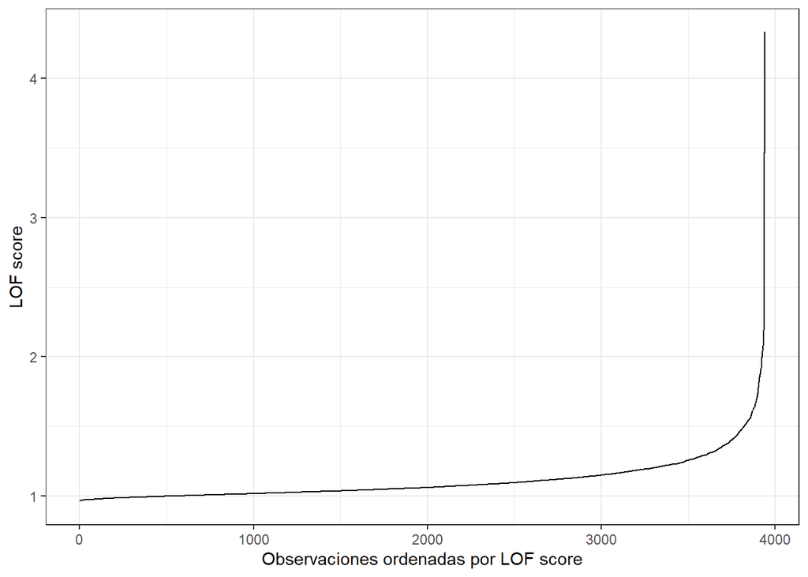

```r
# grafico puntuaciones
lof_scores %>%
  sort() %>%
  data.frame(score = .) %>%
  ggplot(aes(x = seq_along(score), y = score)) +
  geom_line() +
  labs(x = "Observaciones ordenadas por LOF score", y = "LOF score") +
  theme_bw()
```

Para remover outliers vamos a seleccionar solo el 5% con mayor LOF, ya que no tiene sentido que los outliers sean una proporción muy elevada, pues en ese caso ya no serían anómalos.

El código agrega a los datos una columna de LOF score, los ordena de forma descendiente según LOF, retira los n primeros y quita la nueva columna.

```r
# borramos un 5%
n <- round(0.05*dim(df)[1],0)

df <- df %>%
  mutate(lof_score = LOF(select_if(., is.numeric), k = round(sqrt(n()),0))) %>%
  arrange(desc(lof_score)) %>%
  slice(-(1:n)) %>%
  select(-lof_score)
```

Hemos ordenado los datos y eso podría alterar algunas técnicas, por tanto los reordenamos aleatoriamente.

```r
# remezclamos los datos
df <- df[sample(1:dim(df)[1],dim(df)[1]),]
```

## 2.4 Métodos basados en clúster.

Vamos a trabajar con dos métodos, la distancia al centroide y la distancia al medoide.

En primer lugar, necestimos un análisis clúster previo, nosotros lo vamos a hacer a modo de ejemplo con K-Medias, pero podrían utilizarse otros métodos. En consecuencia, las funciones que hemos programado se basan en la salida de este método y podrían no funcionar con otras librerías.

Mediante el estadístico de Hartigan seleccionamos el número de clústers:

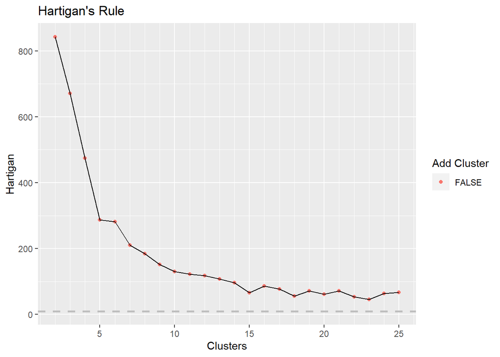

```r
# seleccionamos k con Hartigans
df %>%
  select(where(is.numeric)) %>% # numericas
  FitKMeans(max.clusters=25,
             nstart=10, seed=2023,iter.max=30) %>% # de 2 a 25 clusters
  as.data.frame() %>%
  mutate(AddCluster = FALSE) %>%
  PlotHartigan() # graficamos Hartigan's
```

El número de clúster para el que se reduce significativamente la pendiente es el deseado.

Hacemos el análisis clúster y observamos sus centroides:

```r
# cluster por k means
set.seed(2023) # semilla aleatoria

km_clusters <- df %>%
  select(where(is.numeric)) %>% kmeans(centers = 5 , nstart = 50)

datatable(data.frame(km_clusters$centers),fillContainer=TRUE) # centroides
```

|  | X_2 | X_4 | X_5 | X_8 | X_9 | X_10 | X_12 | X_13 |
| --- | --- | --- | --- | --- | --- | --- | --- | --- |
| 1 | -0.0257668541892645 | 0.190092449293622 | 0.116888824049813 | 0.251559120855321 | 0.888832659231503 | 0.193590271086178 | 1.30844139531042 | 1.09722127407783 |
| 2 | -0.500954842862053 | 0.587938057538389 | -0.739601397532545 | -0.640567357368812 | -0.350232255822486 | -0.262033897983308 | 0.178062398806282 | -0.018750417304329 |
| 3 | 1.33373922653312 | 0.0325222240438158 | 1.24991542260834 | -0.146639870329045 | -0.106217622575338 | 0.0505147685798254 | -0.17262658580028 | -0.171772965694778 |
| 4 | -0.39950137618464 | -1.26091493490377 | -0.327417345222994 | -0.248127256220166 | -0.333549909199639 | -0.220253305895888 | -1.08158966758293 | -0.657918341817616 |
| 5 | -0.117752240586679 | 0.304288573624868 | 0.153488581903644 | 1.20037272915917 | 0.12811228793041 | -0.111686840982866 | 0.00746814183638227 | -0.161290323169687 |

### 2.4.1 Distancia al centroide

Mediante nuestra función `OUTLIERS_KMEDIAS` podemos buscar las n observaciones con mayor distancia al centroide.

```r
# deteccion de outliers
OUTLIERS_KMEDIAS(df,km_clusters,n)
```

```
##   [1]  688 2129 2318 3028 1676 2572 1961 2974 3346  108 3008 2649 2529 3203 3707
##  [16] 1011 1622 2631  638 2776  259  478  121 1001 2690 1154 3627 2089 2697 2843
##  [31] 1837  101 2116 1800 1985 1513 1588 1615 3258 1253 2521 2907 3413 2933  857
##  [46]  811 3520 2916 2188  243  851 2882 2973 1877 2740  482 2515 2210 3703  568
##  [61] 1300 1816 1844 2280 3111 2190 1144  898  170 1262  168 1046 2032 2511 1003
##  [76] 1245 1948 3254 2563  690 2458 1256  738 2762 1665  289  953 2475  570  752
##  [91]  810 1110 2194 3649  258 2753 2477 3040 1702 2449 3366  181 1372 1981 1903
## [106] 3112 1278  463 2235  187 2474 2254  450 1064 1634 3233 1974 2760 2297 3018
## [121] 1247  283 1565 2187 3323 1574 1390 2514 1892 1221 3651 2936  923  320 1775
## [136] 3289 3668 2010 3415 2359  672  675 1207 2024 1507 1787 2459 2059 3363  297
## [151] 2944 2646  897 2794 1845 1057 1070  753  194  787  219 1679  341  734 1842
## [166] 3311 2732 3255 3597  887 2247  348 2827 2027 1895 2388 2071  755  410 1553
## [181]  407 2578 3161  861  536 3720 3606  533 2662 1498 3199 3301 3235 1621 1458
## [196] 3613  485
```

Si quisieramos eliminarlos usaríamos el siguiente código:

```r
# eliminar outliers
# borramos un 5%
n <- round(0.05*dim(df)[1],0)

# df <- df[-OUTLIERS_KMEDIAS(df,km_clusters,n),]
```

### 2.4.2. Distancia al medoide

Establecemos los parámetros:

```r
# deteccion de outliers
n <- round(0.05*dim(df)[1],0) # n a detectar
k <- 5 # numero de clusters
```

Nuestra función `OUTLIERS_KMEDOIDES` detecta las n observaciones más alejadas a sus medoides, para obtener los medoides utiliza la función `pam`.

```r
OUTLIERS_KMEDOIDES(df,n,k)
```

```
##   [1]  688 2129 3707 2318 1513 1800 3346 3258 1676 2572  259  478 3028 1622 2631
##  [16] 2936 1961 2974  738  289 1775 1892  108 2529 1154 3627 2649 1011  857 1001
##  [31] 2194 3649 3520  620 3008  101 2116  541  638 2776 2089 2697 3203  243  851
##  [46] 2916 2843 1702 2449 1985 3190 3274 1245 2174 1253 1588 1615  121 1837 2521
##  [61] 2907 2882 2973 1221  170 2514 2059 3363 1144 3086 2690 3413  690 2587 1457
##  [76] 2933  953 1278 1110  811 2762  482 1262 1948 3254 3323 1025 2420 2732 2210
##  [91] 3703 2477  481  770 1247  568  181  867  194  297 2475 2458 3289 2032 2511
## [106] 1856 2434  165 1679  810 1787 2459  320 2515 2357 2474 2944 1974 1003 1256
## [121] 1390  795 3161 2811 3511 1665 1317 2171 1507 1022 2896 2247  215  463 2235
## [136]  341  410 1816 1844  787 2423 1877 2321 2487 1064  168 1046 1895 2388 2646
## [151]  758  479 2359 3385 3052 2578 2254  408 2563 1300 2298 1579  485 1057 1070
## [166] 1845  812 3544  126  675 2740 2188 1634 3233  898 2763 2024 3366 1458 1050
## [181] 1621 3004 1975 1386 1848  187  730
```

Si quisieramos eliminar outliers lo haríamos de la siguiente manera.

```r
# eliminar outliers
# df <- df[-OUTLIERS_KMEDOIDES(df,n,k),]
```

## 2.5 Análisis de las anomalias

En primer lugar creamos un data frame con los outliers mediante `anti_join` y nuestra columna `ID`

```r
# creamos un data frame con los outliers
# observaciones en df_original que no estan en df
df_outliers <- anti_join(df_original, df, by = "ID")

# los mostramos
datatable(df_outliers,fillContainer=TRUE)
```

|  | X_1 | X_2 | X_4 | X_5 | X_8 | X_9 | X_10 | X_12 | X_13 | X_3 | X_6 | X_7 | ID |
| --- | --- | --- | --- | --- | --- | --- | --- | --- | --- | --- | --- | --- | --- |
| 1 | negativo | -1.06460931322008 | 0.921688396266036 | 0.857243455034611 | -0.617162332119091 | 1.17224526387057 | 9.21704662932444 | 0.679061624427464 | 0.424523354686237 | otros | casado | otros | ID_54 |
| 2 | negativo | -1.06460931322008 | 0.112721525852095 | -0.047123485505825 | 3.21215985457259 | 1.75895907698303 | 0.254766630191744 | 1.13363844625736 | 2.54970189205279 | alquiler | casado | temporal | ID_88 |
| 3 | negativo | -0.945530230350325 | -0.696245344561847 | -1.0419271201003 | -1.12773862367798 | 2.16965874616175 | -0.524562065385012 | -0.911957251977165 | -1.23967283745672 | padres | soltero | temporal | ID_172 |
| 4 | negativo | -0.945530230350325 | -0.696245344561847 | -1.22280050820839 | -1.12773862367798 | -1.17460998857926 | -0.524562065385012 | 1.70185947354473 | 0.67415278350768 | padres | soltero | temporal | ID_200 |
| 5 | negativo | -0.82645114748057 | 0.921688396266036 | -0.770617037938174 | -1.12773862367798 | -0.928190187072026 | 0.0599344562975546 | -0.684668841062218 | 2.08871954682919 | escritura publica | casado | temporal | ID_265 |
| 6 | negativo | -0.945530230350325 | 0.921688396266036 | 1.58073700746696 | -0.617162332119091 | -0.165462230025831 | 2.39792054302782 | 0.906350035342411 | -0.0347947943452182 | escritura publica | casado | otros | ID_271 |
| 7 | negativo | -0.945530230350325 | 0.921688396266036 | -0.047123485505825 | 0.45504788015458 | -1.05726722595677 | -0.524562065385012 | 1.13363844625736 | 2.25513916604349 | alquiler | separado | temporal | ID_295 |
| 8 | negativo | -0.82645114748057 | -1.50521221497579 | 1.94248378368313 | 2.7015835630137 | -1.17460998857926 | -0.524562065385012 | -1.82111089563695 | -1.69732679029603 | alquiler | casado | fijo | ID_312 |
| 9 | negativo | -0.350134816001551 | 0.112721525852095 | 1.85204708962909 | 0.148702105219246 | 2.93238670320794 | 7.85322141206511 | -0.16190549595784 | -0.831944770381693 | escritura publica | casado | autonomo | ID_328 |
| 10 | negativo | -0.58829298174106 | -2.7186625205967 | 0.405059984764393 | -0.617162332119091 | 1.4656021704268 | -0.0569648480389588 | 3.17923414449188 | 3.25365688132926 | escritura publica | casado | fijo | ID_335 |

[output cut: 187 more lines]

Además, retiramos la columna ID y tipificamos de nuevo las variables. Cómo llegados a este punto ese código es repetitivo, queda oculto.

Una métrica importante es la proporción de outliers:

```r
# proporcion de outliers
dim(df_outliers)[1]/dim(df_original)[1]
```

```
## [1] 0.05
```

Además podemos realizar estadística descriptiva sobre nuestros outliers.

Mediante `skim` calculamos las principales estadísticas:

```r
skim(df_outliers)
```

Data summary

| Name | df_outliers |
| --- | --- |
| Number of rows | 197 |
| Number of columns | 12 |
| _______________________ |  |
| Column type frequency: |  |
| factor | 4 |
| numeric | 8 |
| ________________________ |  |
| Group variables | None |

**Variable type: factor**

| skim_variable | n_missing | complete_rate | ordered | n_unique | top_counts |
| --- | --- | --- | --- | --- | --- |
| X_1 | 0 | 1 | FALSE | 2 | pos: 181, neg: 16 |
| X_3 | 0 | 1 | FALSE | 5 | esc: 123, alq: 36, pad: 24, otr: 8 |
| X_6 | 0 | 1 | FALSE | 5 | cas: 156, sol: 33, sep: 4, viu: 3 |
| X_7 | 0 | 1 | FALSE | 4 | aut: 103, fij: 81, otr: 7, tem: 6 |

**Variable type: numeric**

| skim_variable | n_missing | complete_rate | mean | sd | p0 | p25 | p50 | p75 | p100 | hist |
| --- | --- | --- | --- | --- | --- | --- | --- | --- | --- | --- |
| X_2 | 0 | 1 | 0 | 1 | -1.09 | -0.80 | -0.32 | 0.73 | 3.22 | ▇▃▂▁▁ |
| X_4 | 0 | 1 | 0 | 1 | -2.09 | -1.05 | 0.34 | 1.03 | 1.03 | ▂▃▃▃▇ |
| X_5 | 0 | 1 | 0 | 1 | -1.84 | -0.83 | 0.10 | 0.88 | 1.81 | ▆▆▇▇▆ |
| X_8 | 0 | 1 | 0 | 1 | -1.02 | -0.70 | -0.22 | 0.52 | 3.41 | ▇▅▁▁▁ |
| X_9 | 0 | 1 | 0 | 1 | -1.19 | -0.75 | -0.22 | 0.57 | 3.53 | ▇▅▂▁▁ |
| X_10 | 0 | 1 | 0 | 1 | -0.85 | -0.70 | -0.25 | 0.20 | 5.18 | ▇▂▁▁▁ |
| X_12 | 0 | 1 | 0 | 1 | -1.59 | -0.77 | -0.26 | 0.63 | 3.13 | ▅▇▃▂▁ |
| X_13 | 0 | 1 | 0 | 1 | -1.29 | -0.65 | -0.33 | 0.42 | 5.78 | ▇▃▁▁▁ |

Lo comparamos con los datos principales:

```r
skim(df)
```

Data summary

| Name | df |
| --- | --- |
| Number of rows | 3743 |
| Number of columns | 12 |
| _______________________ |  |
| Column type frequency: |  |
| factor | 4 |
| numeric | 8 |
| ________________________ |  |
| Group variables | None |

**Variable type: factor**

| skim_variable | n_missing | complete_rate | ordered | n_unique | top_counts |
| --- | --- | --- | --- | --- | --- |
| X_1 | 0 | 1 | FALSE | 2 | pos: 3259, neg: 484 |
| X_3 | 0 | 1 | FALSE | 6 | esc: 1913, alq: 759, pad: 634, otr: 218 |
| X_6 | 0 | 1 | FALSE | 5 | cas: 2819, sol: 754, sep: 83, viu: 62 |
| X_7 | 0 | 1 | FALSE | 4 | fij: 2685, aut: 615, tem: 332, otr: 111 |

**Variable type: numeric**

| skim_variable | n_missing | complete_rate | mean | sd | p0 | p25 | p50 | p75 | p100 | hist |
| --- | --- | --- | --- | --- | --- | --- | --- | --- | --- | --- |
| X_2 | 0 | 1 | 0 | 1 | -1.07 | -0.82 | -0.34 | 0.63 | 4.62 | ▇▃▂▁▁ |
| X_4 | 0 | 1 | 0 | 1 | -2.77 | -0.72 | 0.10 | 0.92 | 0.92 | ▁▂▅▃▇ |
| X_5 | 0 | 1 | 0 | 1 | -1.77 | -0.85 | -0.11 | 0.71 | 2.82 | ▆▇▅▃▁ |
| X_8 | 0 | 1 | 0 | 1 | -1.16 | -0.70 | 0.08 | 0.99 | 3.72 | ▇▅▃▁▁ |
| X_9 | 0 | 1 | 0 | 1 | -1.98 | -0.66 | -0.20 | 0.45 | 5.67 | ▆▇▂▁▁ |
| X_10 | 0 | 1 | 0 | 1 | -0.84 | -0.84 | -0.14 | 0.37 | 7.23 | ▇▁▁▁▁ |
| X_12 | 0 | 1 | 0 | 1 | -2.19 | -0.70 | 0.05 | 0.67 | 4.27 | ▃▇▅▁▁ |
| X_13 | 0 | 1 | 0 | 1 | -2.75 | -0.61 | -0.05 | 0.53 | 4.92 | ▂▇▅▁▁ |

Podemos estudiar gráficamente la distribución de los outliers mediante un histograma y gráfico de densidad:

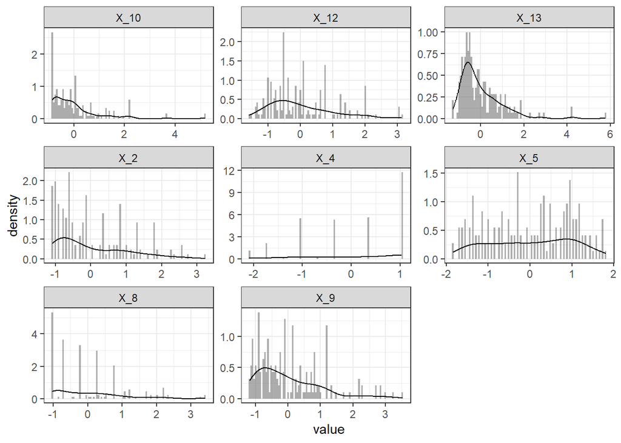

```r
# gather para formato largo requerido
# seleccionamos solo numericas
ggplot(gather(df_outliers |> select(where(is.numeric)), variable, value), aes(x = value)) +
  geom_histogram(aes(y = after_stat(density)),
                 alpha = 0.5, position = "identity",bins=100) + # histogrmas
  geom_density(alpha = 0.5) + # densidad teorica
  facet_wrap(~ variable, scales = "free")+
  theme_bw() # tema
```

A su vez, lo comparamos con los datos principales.

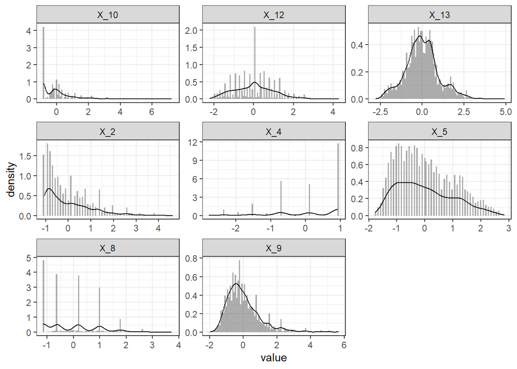

```r
# gather para formato largo requerido
# seleccionamos solo numericas
ggplot(gather(df |> select(where(is.numeric)), variable, value), aes(x = value)) +
  geom_histogram(aes(y = after_stat(density)),
                 alpha = 0.5, position = "identity",bins=100) + # histogrmas
  geom_density(alpha = 0.5) + # densidad teorica
  facet_wrap(~ variable, scales = "free")+
  theme_bw() # tema
```

Cuanto más diferentes sean las distribuciones, más anómalos son los datos.

Podemos comparar mediante un boxplot los outliers y normales:

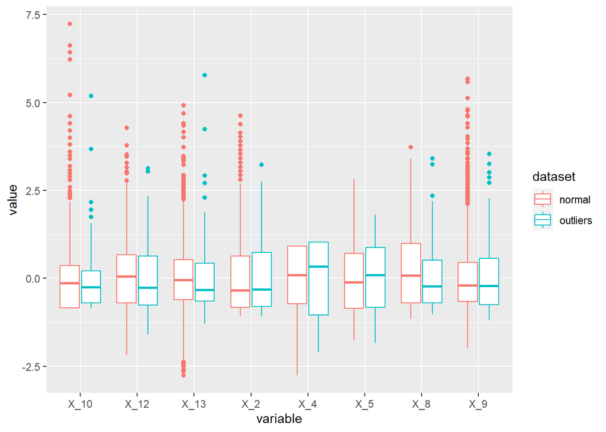

```r
# Unir los datos y agregar la columna "dataset"
df_combined <- bind_rows(
  df_outliers %>%
    mutate(dataset = "outliers"),
  df %>%
    mutate(dataset = "normal")
)

# grafico
ggplot(df_combined %>% pivot_longer(cols = where(is.numeric),
                               names_to = "variable", values_to = "value"),
  aes(x = variable, y = value, color = dataset)) + geom_boxplot()
```

```r
# borrar datos para grafico
rm(df_combined)
```

# 3) Equilibrio en probabilidades a priori

Nuestras probabilidades a priori están desequilibradas:

```r
datatable(p_priori,fillContainer=TRUE)
```

|  | X_1 | n_observaciones | p_priori |
| --- | --- | --- | --- |
| 1 | negativo | 500 | 0.126903553299492 |
| 2 | positivo | 3440 | 0.873096446700508 |

Y esto puede perjudicar la precisión de los clasificadores por clase, en consecuencia, el objetivo de los siguientes apartados es solucionar este problema.

Definimos un objeto con nuestra clase minoritaria para ir usandolo:

```r
# clase minoritaria
clase <- 'negativo'
```

## 3.1 Reducción de observaciones

En este apartado mostramos métodos que equilibran las probabilidades mediante reducir las observaciones de clase mayoritaria.

### 3.1.1 Vínculos de Tomek

El algoritmo de los vínculos de Tomek consiste en buscar la observación de clase mayoritaria más cercana a cada una de las observaciones de clase minoritaria y retirarlas, limpiando así el espacio en que se encuentran las minoritarias.

Este algoritmo lo hemos implementado en nuestra función `tomek`:

```r
vinculos<-df %>%
  select(X_1,where(is.numeric)) %>%
  tomek('X_1',clase) %>%
  mutate_if(is.character, as.numeric)
```

No lo empleamos pues preferimos no retirar observaciones, pero se haría con el siguiente código:

```r
# eliminamos observaciones mayoritarias
# df <- df[-vinculos$majority_index,]
```

### 3.1.2 Eliminación aleatoria.

Una alternativa consiste en eliminar de forma aleatoria observaciones mayoritarias, esto podemos hacerlo con `sample`.

Nuestra función `n_deseada` calcula el número de observaciones a retirar o crear para lograr las probabilidades a priori deseadas:

```r
# n deseada a retirar
n <- n_deseada(c(0.6,0.4),c(dim(df %>% filter(X_1!=clase))[1],
                       dim(df %>% filter(X_1==clase))[1]),'submuestreo')
```

Recogemos n observaciones mayoritarias aleatorias de la siguiente manera:

```r
# semilla aleatoria
set.seed(1998)

# indices positivos aleatorios
df_positivos <- sample(which(df$X_1!=clase),n)
```

Para retirarlas se hace de esta manera:

```r
# retiramos observaciones
# df <- df[-df_positivos,]
```

## 3.2 Generación de observaciones.

Los métodos basados en generar observaciones, como su nombre indica, se basan en crear observaciones sintéticas.

Calculamos el número de observaciones a generar para lograr unas probabilidades de 0.6 mayoritarias y 0.4 minoritarias con nuestra función `n_deseada`.

```r
# numero de observaciones necesarias
n <- n_deseada(c(0.6,0.4),c(dim(df %>% filter(X_1!=clase))[1],
                            dim(df %>% filter(X_1==clase))[1]),'sobremuestreo')
```

### 3.2.1 Datos normales.

Si nuestras variables siguen una distribución normal puede ser una buena idea generar datos normales aleatorios.

Nuestra función `GENERADOR_RNORM` calcula la media y desviación poblacional para cada variable y con un loop emplea `rnorm` para generar `n` datos normales aleatorios para cada variable.

```r
# si las variables pasan test de normalidad
# generamos datos

df_negativos <- df %>%
  filter(X_1==clase) %>% # filtramos por clase
  GENERADOR_RNORM(n) %>% # generamos n datos normales
  mutate(X_1=clase) %>%  # creamos variable clase
  select(X_1,everything()) # reordenamos
```

Solo sirve con variables numéricas, podríamos unir los datos de la siguiente forma:

```r
# unimos por filas
# solo sirve para variables numericas
# df <- df %>% select(X_1,where(is.numeric)) %>% rbind(df_negativos)
```

### 3.2.2 Bootstrap

Una forma de generar datos es tomar muestras aleatorias con remplazamiento de nuestra clase minoritaria.

```r
# creamos muestra de size n de clase minoritaria

# semilla aleatoria
set.seed(1998)

# replica bootstrap
df_negativos<-df %>% filter(X_1 == clase) %>%
  sample_n(size = n, replace = TRUE)
```

Para unir los datos hacemos lo siguiente:

```r
df <- df %>% rbind(df_negativos)
```

Comprobamos que nuestras probabilidades a priori son 0.6 y 0.4:

```r
# calculamos probabilidades a priori
p_priori <- df %>% group_by(X_1) %>%
    summarise('n_observaciones'=n()) %>%
    mutate('p_priori'=n_observaciones/sum(n_observaciones)) %>%
    data.frame()
# mostramos
datatable(p_priori,fillContainer=TRUE)
```

|  | X_1 | n_observaciones | p_priori |
| --- | --- | --- | --- |
| 1 | negativo | 2173 | 0.400036818851252 |
| 2 | positivo | 3259 | 0.599963181148748 |

### 3.2.3 SMOTE

El algoritmo SMOTE consiste en buscar los K vecinos más cercanos a una observación minoritaria y generar un dato sintético mediante una combinación lineal aleatoria de dichos vecinos.

Para el valor de K tomamos la heurística de la raíz del número de observaciones.

```r
# k = sqrt(n observaciones minoritarias)
K<-round(sqrt(dim(df %>% filter(X_1==clase))[1]))
```

Creamos datos mediante SMOTE:

```r
# semilla aleatoria
set.seed(1998)

# generamos datos mediante SMOTE
df_negativos <- SMOTE(df %>% select(where(is.numeric)),
                      df$X_1,K=K )$syn_data %>%
  rename(X_1=class) %>% select(X_1,everything())
```

Solo sirve para variables numéricas.

Si quisieramos usar este método unimos los valores de la siguiente manera:

```r
# unimos por filas
# solo sirve para variables numericas

# df <- df %>% select(X_1,where(is.numeric)) %>% rbind(df_negativos)
```

## 3.3 Preparación previa.

Tras generar las probabilidades a priori tenemos que hacer algunos pasos previos a la validación cruzada. Que son tipificar de nuevo y volver a mezclar los datos. Como ya hemos usado este código, queda oculto.

# 4) Selección mejor modelo enfoque train/test

## 4.1. Preparación previa.

En este apartado vamos a realizar los pasos previos necesarios a la seleción del mejor modelo mediante el enfoque train/test.

En primer lugar separamos los datos en un conjunto de entrenamiento para alimentar la estimación de los modelos y en un conjunto de test para validar su capacidad de generalización fuera de los datos de entrenamiento.

```r
# numero de observaciones
n <- dim(df)[1]

# dividimos muestra en train y test

# fijamos semilla de aleatoriedad
set.seed(102)

#Train 70% aleatorio
train = sample(1:n, 0.70*n,replace = FALSE)
```

Guardamos las clases reales:

```r
# clase real en test
test.clase <- df[-train,]$X_1

# clase real en entrenamiento
train.clase <- df[train,]$X_1
```

Creamos una fórmula con las variables que vamos a emplear:

```r
# formula
formula <- formula(X_1~.)
```

Nosotros utilizaremos todas las variables, pero lo idóneo sería hacer una selección de las mismas por ejemplo mediante el criterio de Akaike de forma automática o seleccionandolas de forma manual empleando contrastes o conocimientos teóricos.

## 4.2. Estimación de los modelos y su precisión.

En este apartado vamos a estimar los modelos y medir su precisión, dado que el código puede ser repetitivo, solo lo vamos a incluir para el primer modelo.

### 4.2.1. Naive Bayes

El clasificador bayesiano ingenuo se fundamenta en el teorema de Bayes para obtener la probabilidad a posteriori de pertenencer a la clase usando la distribución de frecuencias de las variables por clase.

El modelo se estima de la siguiente manera:

```r
# estimacion del modelo
nb.fit <- naiveBayes(formula , data = df ,subset = train)
```

Si dispusieramos de un número reducido de variables podríamos hacer un gráfico de la siguiente manera

```r
# grafico
# partimat(formula, method = "naiveBayes",df[train,])
```

Para predecir en el conjunto de entrenamiento y test hacemos lo siguiente:

```r
# Prediccion

# train
nb.clase.train <- predict(nb.fit , df[train,]) # clase

# test
nb.clase.test <- predict(nb.fit , df[-train,]) # clase
```

Con nuestra función `PRECISION` podemos medir el error:

```r
# train
PRECISION(train.clase, nb.clase.train)
```

```
## [1] "Measurement of the accuracy"
```

```
## $`Confusion Matrix`
##           Prediction
## Real Class negativo positivo
##   negativo     1201      318
##   positivo      467     1816
##
## $`Class Accuracy`
##  negativo  positivo
## 0.7906517 0.7954446
##
## $`Global Accuracy`
## [1] 0.7935297
##
## $`Class Error`
##  negativo  positivo
## 0.2093483 0.2045554
##
## $`Global Error`
## [1] 0.2064703
```

```r
# test
PRECISION(test.clase, nb.clase.test)
```

```
## [1] "Measurement of the accuracy"
```

```
## $`Confusion Matrix`
##           Prediction
## Real Class negativo positivo
##   negativo      527      127
##   positivo      177      799
##
## $`Class Accuracy`
##  negativo  positivo
## 0.8058104 0.8186475
##
## $`Global Accuracy`
## [1] 0.8134969
##
## $`Class Error`
##  negativo  positivo
## 0.1941896 0.1813525
##
## $`Global Error`
## [1] 0.1865031
```

En adelante trabajaremos con `confusionMatrix` del paquete `caret` por ser más eficiente y completa.

A continuación guardamos las medidas de precisión:

```r
# train

# guardamos datos
nb.train.precision <- confusionMatrix(nb.clase.train ,train.clase)$overall[1]
nb.train.kappa<- confusionMatrix(nb.clase.train ,train.clase)$overall[2]
nb.train.sensibilidad <- confusionMatrix(nb.clase.train ,train.clase)$byClass[1]
nb.train.especificidad<- confusionMatrix(nb.clase.train ,train.clase)$byClass[2]

# test

# guardamos datos
nb.test.precision <- confusionMatrix(nb.clase.test ,test.clase)$overall[1]
nb.test.kappa<- confusionMatrix(nb.clase.test ,test.clase)$overall[2]
nb.test.sensibilidad <- confusionMatrix(nb.clase.test ,test.clase)$byClass[1]
nb.test.especificidad<- confusionMatrix(nb.clase.test ,test.clase)$byClass[2]
```

Esto nos permite crear una tabla para almacenar las medidas de precisión:

```r
nb.medidas <- data.frame(
  Modelo = rep("Naive Bayes", 2),
  Train_Test = c("Train", "Test"),
  Precisión = c(nb.train.precision, nb.test.precision),
  Kappa = c(nb.train.kappa, nb.test.kappa),
  Sensibilidad = c(nb.train.sensibilidad, nb.test.sensibilidad),
  Especificidad = c(nb.train.especificidad, nb.test.especificidad),
  Llamada = c('nb.fit','nb.fit')
)

# la mostramos
datatable(nb.medidas,fillContainer=TRUE)
```

|  | Modelo | Train_Test | Precisión | Kappa | Sensibilidad | Especificidad | Llamada |
| --- | --- | --- | --- | --- | --- | --- | --- |
| 1 | Naive Bayes | Train | 0.793529721199369 | 0.576632116193991 | 0.790651744568795 | 0.795444590451161 | nb.fit |
| 2 | Naive Bayes | Test | 0.813496932515337 | 0.616680642496217 | 0.805810397553517 | 0.818647540983607 | nb.fit |

La columna `Llamada` nos permitirá más adelante seleccionar el mejor modelo.

### 4.2.2 K Nearest Neighbors KNN

El algoritmo KNN busca los K vecinos más cercanos a una observación y asigna la clase mayoritaria entre ellos.

El modelo se estima con la función `train.kknn`

```r
# heuristica de mejor K
K <- round(sqrt(dim(df)[1]))

# buscamos como mucho hasta el doble de K
knn.fit<-train.kknn(formula, data = df[train,], kmax = 2*K)
# usar K -> quitamos kmax y ponemos ks=K

# mejor K
knn.fit$best.parameters[2]
```

```
## $k
## [1] 1
```

De nuevo, predecimos y calculamos la precisión del modelo:

|  | Modelo | Train_Test | Precisión | Kappa | Sensibilidad | Especificidad | Llamada |
| --- | --- | --- | --- | --- | --- | --- | --- |
| 1 | KNN | Train | 0.999473961073119 | 0.998903893484509 | 1 | 0.999123959702146 | knn.fit |
| 2 | KNN | Test | 0.965030674846626 | 0.927858073513174 | 0.983180428134557 | 0.952868852459016 | knn.fit |

### 4.2.3 Clasificación logística.

La clasificación logística estima las probabilidades a posteriori con una función logística y a partir de un umbral (tradicionalmente 0.5) clasifica. Se emplea habitualmente en problemas dicotómicos, pero su versión multinomial se puede emplear en problemas con más de dos clases.

La estimación la hacemos con `train` o `multinom` según el caso.

```r
# estimacion
log.fit <- train(formula, data = df[train,],
                 method = "glm", family = "binomial")

# para clasificacion no binaria
# log.fit <- multinom(formula , family = binomial, data = df, subset=train)
```

Podemos estudiar la importancia de las variables:

```r
# importancia variables
summary(log.fit)$coefficients %>%
  data.frame() %>% arrange(Estimate) %>%
  datatable(fillContainer=TRUE)
```

|  | Estimate | Std..Error | z.value | Pr...z.. |
| --- | --- | --- | --- | --- |
| X_7temporal | -4.17934066474757 | 0.241157755389953 | -17.3303183137924 | 2.77786789043933e-67 |
| X_7otros | -2.31154571966279 | 0.259686531765291 | -8.90129227707505 | 5.5200188955437e-19 |
| X_6separado | -1.94748454014229 | 0.286403279503064 | -6.79979832466078 | 1.0476570643002e-11 |
| X_6soltero | -0.901521591558021 | 0.176350437672674 | -5.11210294374969 | 3.18592120766273e-07 |
| X_12 | -0.889713844631008 | 0.103295292851217 | -8.61330482805753 | 7.09840232245914e-18 |
| X_8 | -0.706984822439071 | 0.0754939684590716 | -9.36478551690334 | 7.62049084483884e-21 |
| X_3otros | -0.679257283416793 | 0.220402708973416 | -3.08189171803111 | 0.00205689645263893 |
| X_6viudo | -0.539993208160454 | 0.414386170133285 | -1.30311590270199 | 0.192535195188031 |
| X_6divorciado | -0.220204638078217 | 0.741011679588956 | -0.29716756718378 | 0.766338581645119 |
| `X_3contrato privado` | -0.137872163747807 | 0.253210556208289 | -0.544496113481127 | 0.58610012215963 |

[output cut: 11 more lines]

De nuevo, predecimos y calculamos la precisión:

|  | Modelo | Train_Test | Precisión | Kappa | Sensibilidad | Especificidad | Llamada |
| --- | --- | --- | --- | --- | --- | --- | --- |
| 1 | Logistica | Train | 0.871646501841136 | 0.723914952682214 | 0.746543778801843 | 0.954883924660534 | log.fit |
| 2 | Logistica | Test | 0.877300613496933 | 0.737892397593113 | 0.769113149847095 | 0.949795081967213 | log.fit |

### 4.2.4 Analisis Discriminante Lineal (LDA)

El LDA trata de buscar la combinación de funciones lineales que mejor discriminan los datos basandose en el teorema de Bayes.

La estimación se hace con la función `lda`

```r
# estimacion
lda.fit <- lda(formula , data = df , subset = train)
```

Si tuvieramos pocas variables podríamos representar gráficamente:

```r
# partimat(formula, method = "lda",df[train,])
```

Podemos ver la clase que se asigna según la puntuación:

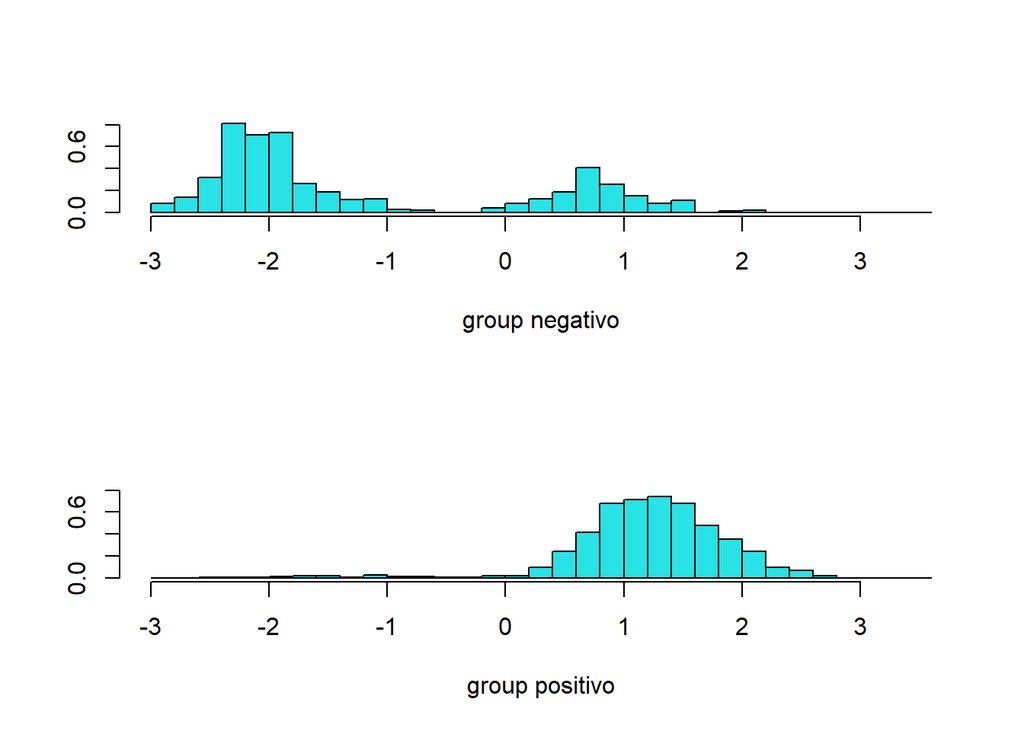

```r
# Grafico
plot(lda.fit)
```

También, con valores tipificados podemos estudiar la importancia de las variables

```r
# importancia variables
as.data.frame(abs(lda.fit$scaling)) %>%
  arrange(desc(LD1)) %>% datatable(fillContainer=TRUE)
```

|  | LD1 |
| --- | --- |
| X_7temporal | 2.59808445342843 |
| X_7otros | 1.94691074547501 |
| X_6separado | 0.864477984092271 |
| X_7fijo | 0.375321805516008 |
| X_6soltero | 0.370512563392557 |
| X_12 | 0.33150217816474 |
| X_8 | 0.284188627377991 |
| X_3otros | 0.278979016828165 |
| X_2 | 0.207729710025614 |
| X_13 | 0.203808096319871 |

[output cut: 10 more lines]

De nuevo predecimos y calculamos la precisión:

|  | Modelo | Train_Test | Precisión | Kappa | Sensibilidad | Especificidad | Llamada |
| --- | --- | --- | --- | --- | --- | --- | --- |
| 1 | LDA | Train | 0.864544976328248 | 0.70532321394441 | 0.705069124423963 | 0.970652650021901 | lda.fit |
| 2 | LDA | Test | 0.868711656441718 | 0.715717755211814 | 0.718654434250764 | 0.969262295081967 | lda.fit |

Otras medidas de precisión importantes en LDA son la Lambda de Wilks y la correlación canónica. Estas se obtienen con `manova`.

```r
#Lambda de Wilks

df.num = df %>%
  select_if(is.numeric) %>%
  as.matrix() #solo numericas

df.manova<-manova(df.num~df$X_1)

(df.wilks<-summary(df.manova, test="Wilks"))
```

```
##             Df   Wilks approx F num Df den Df    Pr(>F)
## df$X_1       1 0.72396   258.46      8   5423 < 2.2e-16 ***
## Residuals 5430
## ---
## Signif. codes:  0 '***' 0.001 '**' 0.01 '*' 0.05 '.' 0.1 ' ' 1
```

```r
# con autovalores

1/(1+df.wilks$Eigenvalues[1])
```

```
## [1] 0.7239641
```

```r
# correlacion canonica. eta^2

(eta2<- df.wilks$Eigenvalues[1]/(1+ df.wilks$Eigenvalues[1]))
```

```
## [1] 0.2760359
```

```r
(corr.canonica<-sqrt(eta2))
```

```
## [1] 0.5253912
```

### 4.2.5 Analisis Discriminante Cuadratico (QDA)

El QDA trata de buscar la combinación de funciones cuadráticas que mejor discriminan los datos basandose en el teorema de Bayes.

La estimación se hace con la función `qda`

```r
# estimacion
qda.fit <- qda(formula , data = df , subset = train)
```

Si tuvieramos pocas variables podríamos representar:

```r
# grafico
# partimat(formula, method = "qda",df[train,])
```

De nuevo predecimos y calculamos la precisión:

|  | Modelo | Train_Test | Precisión | Kappa | Sensibilidad | Especificidad | Llamada |
| --- | --- | --- | --- | --- | --- | --- | --- |
| 1 | QDA | Train | 0.860599684376644 | 0.701104973850802 | 0.741935483870968 | 0.939553219448095 | qda.fit |
| 2 | QDA | Test | 0.860736196319018 | 0.703199423741158 | 0.755351681957186 | 0.931352459016393 | qda.fit |

### 4.2.6 Árbol de clasificación

El árbol de clasificación es un algoritmo voraz que calcula todas las particiones posibles en todas las variables y selecciona aquella que minimiza la variación de una medida de desorden como la función de entropía o el coeficiente de Gini, acto seguido reitera hasta que clasifica a la perfección los datos de entrenamiento o alcanza un criterio de parada.

Lo estimamos con `rpart`, en primer lugar un árbol completo:

```r
# estimacion arbol sobreajustado
tree.fit <- rpart(formula, data=df, subset=train,
                     method="class", parms=list(split="information"),
                     control=rpart.control(cp=0.001,xval=30,
                                           maxdepth=10,minsplit=2,minbucket=1))
```

Podemos estudiar la importancia de las variables:

```r
# importancia de las variables
tree.fit$variable.importance %>% data.frame() %>% datatable(fillContainer = TRUE)
```

|  | . |
| --- | --- |
| X_7 | 1126.79435625691 |
| X_2 | 545.45561456239 |
| X_5 | 305.436610777665 |
| X_9 | 293.924537599148 |
| X_13 | 228.181134302117 |
| X_12 | 178.037371347498 |
| X_8 | 148.610990881277 |
| X_10 | 125.981623881571 |
| X_3 | 98.711361664605 |
| X_4 | 71.756382739287 |

[output cut: 1 more lines]

Mediante el gráfico de coste/complejidad podemos decidir como podar el árbol:

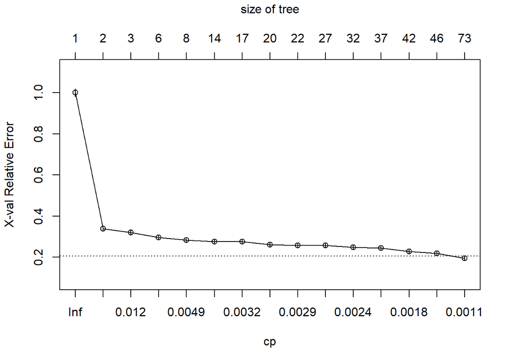

```r
# error nodos vs coste complejidad
plotcp(tree.fit)
```

```r
# podado manual maxdepth en base a plotcp
```

Nosotros vamos a podarlo con `autoprune` de la librería `adabag`.

```r
# podado automatico
tree.fit <- autoprune(formula=formula, data=df, subset=train)
```

Podemos representarlo gráficamente, ponemos un ejemplo con 3 nodos por motivos de espacio:

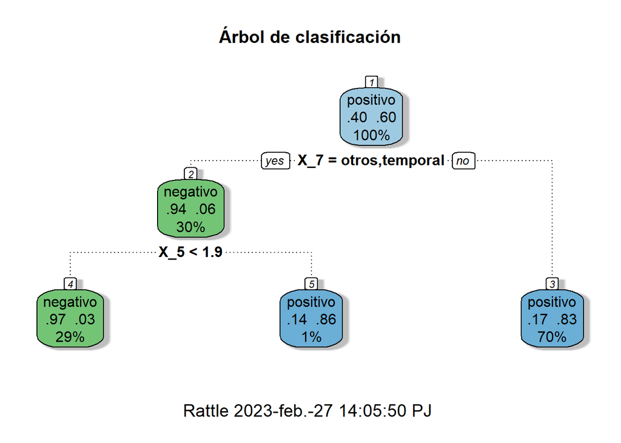

Si tiene muchos nodos puede ser un poco contraintuitivo.

Podemos ver gráficamente la importancia de las variables:

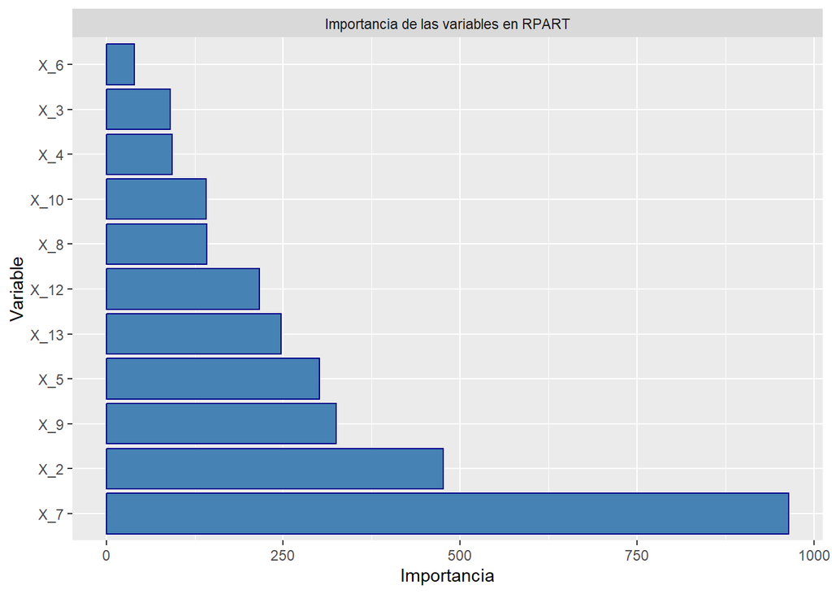

```r
# tabla importancia

Importance <- data.frame(names(tree.fit$variable.importance), tree.fit$variable.importance,
                         prop.table(tree.fit$variable.importance)*100)

names(Importance) <- c("variable","importance","percent")

Importance$variable <- as.factor(Importance$variable)

# graficos importancia

ggplot(data=Importance, aes(x=reorder(variable,-importance), y=importance)) +
  labs(x="Variable",y= "Importancia") +
  geom_bar(col="darkblue",fill="steelblue",stat="identity") +
  #ggtitle("Importancia de las variables en RPART") +
  facet_wrap(~"Importancia de las variables en RPART") +
  coord_flip()
```

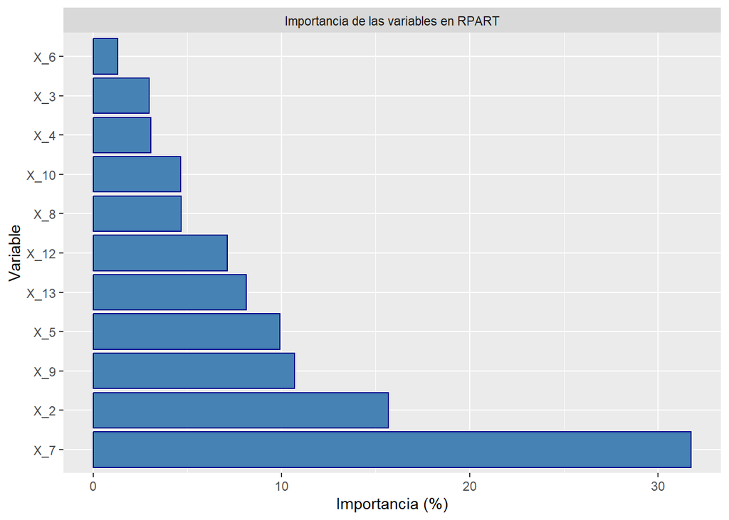

```r
ggplot(data=Importance, aes(x=reorder(variable,-importance), y=percent)) +
  labs(x="Variable",y= "Importancia (%)") +
  geom_bar(col="darkblue",fill="steelblue",stat="identity") +
  #ggtitle("Importancia de las variables en RPART") +
  facet_wrap(~"Importancia de las variables en RPART") +
  coord_flip()
```

Como acostumbramos, predecimos y calculamos las medidas de precisión:

|  | Modelo | Train_Test | Precisión | Kappa | Sensibilidad | Especificidad | Llamada |
| --- | --- | --- | --- | --- | --- | --- | --- |
| 1 | Arbol | Train | 0.998158863755918 | 0.996164894271608 | 0.999341672152732 | 0.997371879106439 | tree.fit |
| 2 | Arbol | Test | 0.957055214723926 | 0.911647643679051 | 0.981651376146789 | 0.940573770491803 | tree.fit |

### 4.2.7 Bagging

El bagging consiste en crear réplicas bootstrap de los datos, estimar un modelo para cada una de ellas y unir los resultados. En nuestro caso los modelos serán árboles.

Requerimos unos parámetros previos, en adelante no se repetirán:

```r
# parametros
maxdepth <- 5
mfinal <- 250
cntrl<-rpart.control(maxdepth=maxdepth, cp=-1, minsplit=5, minbucket=2)
```

Estimamos de la siguiente manera:

```r
# semilla de aleatoriedad
set.seed(1998)
# estimacion
bag.fit<- bagging(formula=formula,
                  data=df,
                  subset=train,
                  mfinal=mfinal,
                  control=cntrl)
```

Podemos representar gráficamente la importancia de las variables:

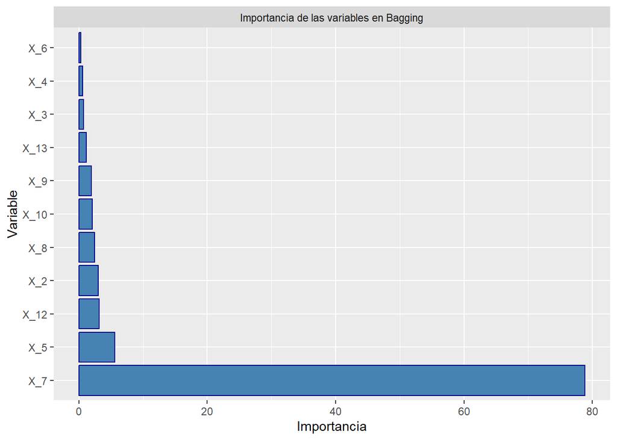

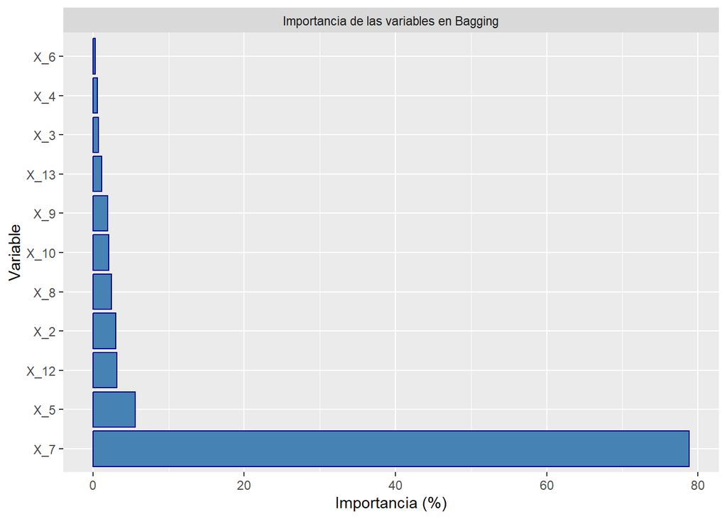

De nuevo predecimos y estimamos la precisión:

|  | Modelo | Train_Test | Precisión | Kappa | Sensibilidad | Especificidad | Llamada |
| --- | --- | --- | --- | --- | --- | --- | --- |
| 1 | Bagging | Train | 0.890057864281957 | 0.762274122900836 | 0.754443712969059 | 0.980289093298292 | bag.fit |
| 2 | Bagging | Test | 0.897546012269939 | 0.779254227831759 | 0.769113149847095 | 0.983606557377049 | bag.fit |

### 4.2.8 Boosting

El boosting es similar al bagging, consiste en crear una réplica bootstrap de los datos y secuencialmente estimar modelos, solo que sobre los errores del primero se construye la siguiente réplica dándoles más importancia.

Estimamos el modelo con la siguiente función:

```r
# semilla de aleatoriedad
set.seed(1998)
# estimacion
boost.fit<- boosting(formula=formula, data=df, subset=train ,mfinal=mfinal,
                     coeflearn="Freund", boos=T, control=cntrl)
```

También podemos mostrar gráficamente la importancia de las variables:

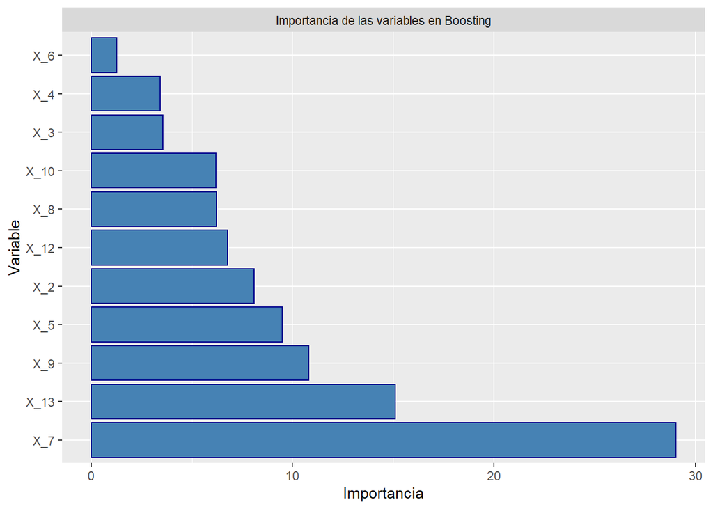

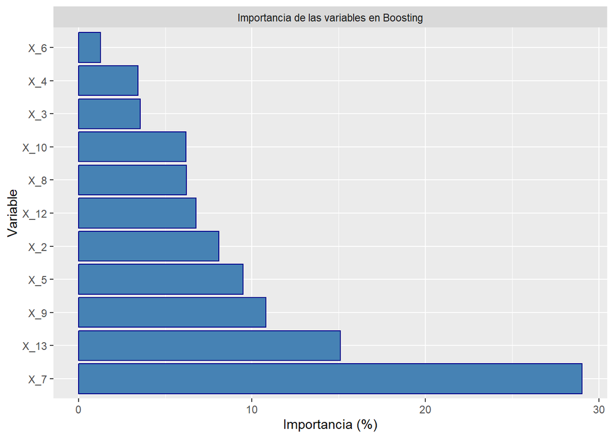

De nuevo predecimos y estimamos la precisión:

|  | Modelo | Train_Test | Precisión | Kappa | Sensibilidad | Especificidad | Llamada |
| --- | --- | --- | --- | --- | --- | --- | --- |
| 1 | Boosting | Train | 0.99132035770647 | 0.981928174193353 | 0.992100065832785 | 0.990801576872536 | boost.fit |
| 2 | Boosting | Test | 0.993865030674847 | 0.987244658407257 | 0.995412844036697 | 0.992827868852459 | boost.fit |

### 4.2.9 Random Forest

El algoritmo de Random Forest también construye varias réplicas aleatorias de los datos, pero además selecciona `m` variables aleatorias para cada estimación, para evitar que ciertas variables acaparen todas las iteraciones eclipsando al resto.

Tomamos `m` como la raíz del número de variables. Se estima de la siguiente forma:

```r
# semilla de aleatoriedad
set.seed(1998)
# mtry=sqr(p) para clasificacion
forest.fit<- randomForest(formula=formula, data=df,
                          subset=train, ntree=mfinal,
                          mtry=round(sqrt(dim(df)[2])), nodesize=1,
                          replace=T, importance=T)
```

De nuevo podemos estudiar la importancia de las variables, solo que en este caso mediante la reducción del coeficiente de Gini:

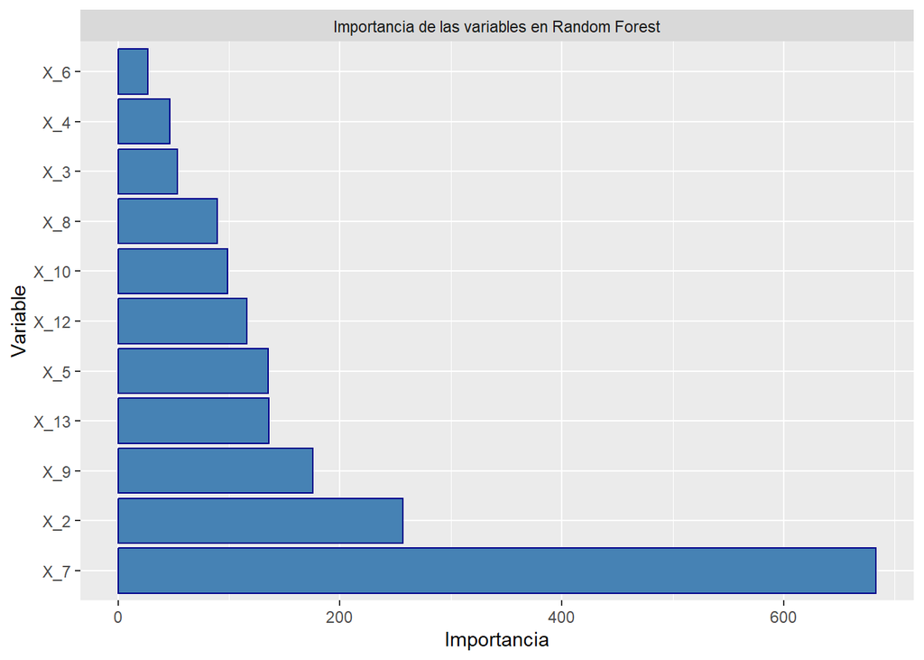

De nuevo, predecimos y calculamos la precisión:

|  | Modelo | Train_Test | Precisión | Kappa | Sensibilidad | Especificidad | Llamada |
| --- | --- | --- | --- | --- | --- | --- | --- |
| 1 | Random_Forest | Train | 0.999473961073119 | 0.998903893484509 | 1 | 0.999123959702146 | forest.fit |
| 2 | Random_Forest | Test | 0.984662576687117 | 0.968103608871189 | 0.983180428134557 | 0.985655737704918 | forest.fit |

### 4.2.10 Máquinas de Vector de Soporte (SVM)

El algoritmo SVM trata de buscar el mejor hiperplano que separa los datos y para ello se apoya en proyectar los datos a otra dimensión, mediante funciones como puede ser por ejemplo, una campana gaussiana.

Se estima con el siguiente código:

```r
# estimacion
svm.fit<- svm(formula, data = df, subset=train,
              type = "C-classification",
              kernel = "radial",
              probability =T)
```

De nuevo predecimos y estimamos la precisión:

|  | Modelo | Train_Test | Precisión | Kappa | Sensibilidad | Especificidad | Llamada |
| --- | --- | --- | --- | --- | --- | --- | --- |
| 1 | SVM | Train | 0.882430299842188 | 0.745577646323685 | 0.742593811718236 | 0.975470871660096 | svm.fit |
| 2 | SVM | Test | 0.889570552147239 | 0.762380663908749 | 0.762996941896025 | 0.974385245901639 | svm.fit |

### 4.2.11 Clasificación mediante red neuronal.

En este caso vamos a emplear una red de perceptrones con una única capa oculta. La red neuronal consiste en estimar mediante descenso de gradiente u otro algoritmo múltiples funciones lineales sobre las que se aplica una función de transformación como por ejemplo la sigmoidea (o logística) y despúes se pone en común el resultado.

Estimamos a modo de ejemplo, una red muy sencilla con tantas neuronas como la ráiz de cuatro veces el número de variables.

```r
net.fit<- nnet(formula, data=df, size = round(sqrt(4*dim(df)[2])),
               maxit=50, decay=0.1, subset=train)
```

Redes muy sencillas podrían representarse:

```r
# grafico
# plot(net.fit, cex.val=0.7, main="Red Neuronal")
```

Por último, predecimos y estimamos la precisión

|  | Modelo | Train_Test | Precisión | Kappa | Sensibilidad | Especificidad | Llamada |
| --- | --- | --- | --- | --- | --- | --- | --- |
| 1 | Red Neuronal | Train | 0.914518674381904 | 0.819396467177703 | 0.852534562211982 | 0.955759964958388 | net.fit |
| 2 | Red Neuronal | Test | 0.904907975460123 | 0.799205883708695 | 0.837920489296636 | 0.949795081967213 | net.fit |

## 4.3 Análisis de la precisión.

En este apartado vamos a comparar la precisión de los modelos y seleccionar el mejor.

Creamos una tabla que resume la precisión de todos los modelos:

```r
tabla_precision <- rbind(nb.medidas,knn.medidas,log.medidas,
                         lda.medidas,qda.medidas,tree.medidas,
                         bag.medidas,boost.medidas,forest.medidas,
                         svm.medidas,net.medidas)

datatable(tabla_precision,fillContainer = TRUE)
```

|  | Modelo | Train_Test | Precisión | Kappa | Sensibilidad | Especificidad | Llamada |
| --- | --- | --- | --- | --- | --- | --- | --- |
| 1 | Naive Bayes | Train | 0.793529721199369 | 0.576632116193991 | 0.790651744568795 | 0.795444590451161 | nb.fit |
| 2 | Naive Bayes | Test | 0.813496932515337 | 0.616680642496217 | 0.805810397553517 | 0.818647540983607 | nb.fit |
| 3 | KNN | Train | 0.999473961073119 | 0.998903893484509 | 1 | 0.999123959702146 | knn.fit |
| 4 | KNN | Test | 0.965030674846626 | 0.927858073513174 | 0.983180428134557 | 0.952868852459016 | knn.fit |
| 5 | Logistica | Train | 0.871646501841136 | 0.723914952682214 | 0.746543778801843 | 0.954883924660534 | log.fit |
| 6 | Logistica | Test | 0.877300613496933 | 0.737892397593113 | 0.769113149847095 | 0.949795081967213 | log.fit |
| 7 | LDA | Train | 0.864544976328248 | 0.70532321394441 | 0.705069124423963 | 0.970652650021901 | lda.fit |
| 8 | LDA | Test | 0.868711656441718 | 0.715717755211814 | 0.718654434250764 | 0.969262295081967 | lda.fit |
| 9 | QDA | Train | 0.860599684376644 | 0.701104973850802 | 0.741935483870968 | 0.939553219448095 | qda.fit |
| 10 | QDA | Test | 0.860736196319018 | 0.703199423741158 | 0.755351681957186 | 0.931352459016393 | qda.fit |

[output cut: 12 more lines]

Podemos ver la precisión en test ordenada por sensibilidad, que es la precisión en la clase de interés:

```r
# precision en test ordenada por sensibilidad
tabla_precision %>% filter(Train_Test=='Test') %>%
  arrange(desc(Sensibilidad)) %>%
  datatable(fillContainer = TRUE)
```

|  | Modelo | Train_Test | Precisión | Kappa | Sensibilidad | Especificidad | Llamada |
| --- | --- | --- | --- | --- | --- | --- | --- |
| 1 | Boosting | Test | 0.993865030674847 | 0.987244658407257 | 0.995412844036697 | 0.992827868852459 | boost.fit |
| 2 | KNN | Test | 0.965030674846626 | 0.927858073513174 | 0.983180428134557 | 0.952868852459016 | knn.fit |
| 3 | Random_Forest | Test | 0.984662576687117 | 0.968103608871189 | 0.983180428134557 | 0.985655737704918 | forest.fit |
| 4 | Arbol | Test | 0.957055214723926 | 0.911647643679051 | 0.981651376146789 | 0.940573770491803 | tree.fit |
| 5 | Red Neuronal | Test | 0.904907975460123 | 0.799205883708695 | 0.837920489296636 | 0.949795081967213 | net.fit |
| 6 | Naive Bayes | Test | 0.813496932515337 | 0.616680642496217 | 0.805810397553517 | 0.818647540983607 | nb.fit |
| 7 | Logistica | Test | 0.877300613496933 | 0.737892397593113 | 0.769113149847095 | 0.949795081967213 | log.fit |
| 8 | Bagging | Test | 0.897546012269939 | 0.779254227831759 | 0.769113149847095 | 0.983606557377049 | bag.fit |
| 9 | SVM | Test | 0.889570552147239 | 0.762380663908749 | 0.762996941896025 | 0.974385245901639 | svm.fit |
| 10 | QDA | Test | 0.860736196319018 | 0.703199423741158 | 0.755351681957186 | 0.931352459016393 | qda.fit |

[output cut: 1 more lines]

El modelo con mayor sensibilidad en test es:

```r
# modelo mayor sensibilidad en test
tabla_precision %>%
  filter(Train_Test=='Test') %>%
  arrange(desc(Sensibilidad)) %>%
  slice(1) %>% datatable(fillContainer = TRUE)
```

|  | Modelo | Train_Test | Precisión | Kappa | Sensibilidad | Especificidad | Llamada |
| --- | --- | --- | --- | --- | --- | --- | --- |
| 1 | Boosting | Test | 0.993865030674847 | 0.987244658407257 | 0.995412844036697 | 0.992827868852459 | boost.fit |

Más tarde volveremos a usar esta tabla para recoger el mejor modelo y predecir con él.

# 5) Validación cruzada K-Folds

## 5.1 Preparación previa

Hacemos algunas operaciones y creamos algunos objetos necesarios:

```r
# numero de observaciones
n <- dim(df)[1]

# numero de carpetas
K <- 10

# formula
formula <- formula(X_1~.)

# fijamos semilla aleatoria
set.seed(1998)
```

## 5.2 K-Folds mediante loop

En este apartado vamos a realizar una validación cruzada en 10 carpetas mediante un loop `for`. Esto consiste en separar los datos en 10 partes, y entrenar los modelos con 9 carpetas y validarlos en 1 y así sucesivamente hasta emplear las 10 carpetas en validación, después usamos el error promedio como un estimador del error de test.

Antes de ejecutar el loop creamos algunos objetos necesarios para su ejecución

```r
# reordenamos los datos
vc = sample(1:n)

# parametros
maxdepth <- 1
mfinal <- 50
cntrl<-rpart.control(maxdepth=maxdepth, cp=-1, minsplit=5, minbucket=2)

# vectores de K elementos para almacenar la precision de las 10 carpetas
error.nb.Kf = rep(0,K)        # Para Naive Bayes
error.knn.Kf = rep(0,K)       # Para knn
error.log.Kf = rep(0,K)       # Para logistica
error.lda.Kf = rep(0,K)       # Para lda
error.qda.Kf = rep(0,K)       # Para qda
error.tree.Kf = rep(0,K)      # Para arbol
error.bag.Kf = rep(0,K)       # Para bag
error.boost.Kf = rep(0,K)     # Para boost
error.forest.Kf = rep(0,K)    # Para random forest
error.svm.Kf = rep(0,K)       # Para svm
error.net.Kf = rep(0,K)       # Para random net
```

No vamos a mostrar el código del loop ya que es excesivamente extenso, pero lo ejecutamos para obtener los errores de las 10 carpetas por modelo, con los que construimos la siguiente tabla:

```r
# Errores en cada una de las K carpetas

# Unir los vectores en una tabla
tabla_errores <- data.frame(
  Naive_Bayes = error.nb.Kf,
  knn = error.knn.Kf,
  logistica = error.log.Kf,
  lda = error.lda.Kf,
  qda = error.qda.Kf,
  arbol = error.tree.Kf,
  bagging = error.bag.Kf,
  boosting = error.boost.Kf,
  random_forest = error.forest.Kf,
  svm = error.svm.Kf,
  net = error.net.Kf
)

datatable(tabla_errores,fillContainer = TRUE)
```

|  | Naive_Bayes | knn | logistica | lda | qda | arbol | bagging | boosting | random_forest | svm | net |
| --- | --- | --- | --- | --- | --- | --- | --- | --- | --- | --- | --- |
| 1 | 0.204419889502762 | 0.0257826887661142 | 0.121546961325967 | 0.132596685082873 | 0.141804788213628 | 0.0386740331491713 | 0.132596685082873 | 0.128913443830571 | 0.0128913443830571 | 0.10865561694291 | 0.104972375690608 |
| 2 | 0.233766233766234 | 0.038961038961039 | 0.116883116883117 | 0.12987012987013 | 0.12987012987013 | 0.025974025974026 | 0.12987012987013 | 0.12987012987013 | 0.012987012987013 | 0.116883116883117 | 0.142857142857143 |
| 3 | 0.22972972972973 | 0.0135135135135135 | 0.0945945945945946 | 0.081081081081081 | 0.108108108108108 | 0 | 0.081081081081081 | 0.108108108108108 | 0 | 0.0675675675675675 | 0.108108108108108 |
| 4 | 0.22972972972973 | 0.027027027027027 | 0.121621621621622 | 0.175675675675676 | 0.162162162162162 | 0.0945945945945946 | 0.175675675675676 | 0.148648648648649 | 0.0405405405405406 | 0.175675675675676 | 0.189189189189189 |
| 5 | 0.135135135135135 | 0.0135135135135135 | 0.121621621621622 | 0.135135135135135 | 0.148648648648649 | 0.027027027027027 | 0.135135135135135 | 0.108108108108108 | 0 | 0.081081081081081 | 0.108108108108108 |
| 6 | 0.175675675675676 | 0.0405405405405406 | 0.081081081081081 | 0.0675675675675675 | 0.081081081081081 | 0.0405405405405406 | 0.0675675675675675 | 0.081081081081081 | 0.0135135135135135 | 0.0405405405405406 | 0.0675675675675675 |
| 7 | 0.189189189189189 | 0.0135135135135135 | 0.135135135135135 | 0.135135135135135 | 0.162162162162162 | 0.0675675675675675 | 0.135135135135135 | 0.135135135135135 | 0.0135135135135135 | 0.121621621621622 | 0.121621621621622 |
| 8 | 0.256756756756757 | 0.027027027027027 | 0.189189189189189 | 0.189189189189189 | 0.162162162162162 | 0.0135135135135135 | 0.189189189189189 | 0.189189189189189 | 0.027027027027027 | 0.189189189189189 | 0.175675675675676 |
| 9 | 0.189189189189189 | 0.027027027027027 | 0.135135135135135 | 0.135135135135135 | 0.148648648648649 | 0.0135135135135135 | 0.135135135135135 | 0.108108108108108 | 0 | 0.135135135135135 | 0.108108108108108 |
| 10 | 0.22972972972973 | 0.027027027027027 | 0.22972972972973 | 0.27027027027027 | 0.243243243243243 | 0.0540540540540541 | 0.27027027027027 | 0.22972972972973 | 0.0135135135135135 | 0.22972972972973 | 0.216216216216216 |

Después, creamos una tabla con los errores promedios:

```r
# Errores medios para cada tecnica
tabla_errores_medios <- data.frame(
  Modelo = c("Naive Bayes", "knn", "Logística", "lda",
             "qda", "Arbol", "Bagging", "Boosting",
             "Random Forest", "SVM", "Red Neuronal"),
  Error_Medio = c(mean(error.nb.Kf), mean(error.knn.Kf),
                  mean(error.log.Kf), mean(error.lda.Kf),
                  mean(error.qda.Kf), mean(error.tree.Kf),
                  mean(error.bag.Kf), mean(error.boost.Kf),
                  mean(error.forest.Kf), mean(error.svm.Kf),
                  mean(error.net.Kf))
)

datatable(tabla_errores_medios,fillContainer = TRUE)
```

|  | Modelo | Error_Medio |
| --- | --- | --- |
| 1 | Naive Bayes | 0.207332125840413 |
| 2 | knn | 0.0253932916916342 |
| 3 | Logística | 0.134653818631719 |
| 4 | lda | 0.145165600414219 |
| 5 | qda | 0.148789113429997 |
| 6 | Arbol | 0.0375458869934008 |
| 7 | Bagging | 0.145165600414219 |
| 8 | Boosting | 0.136689168180881 |
| 9 | Random Forest | 0.0133986465478178 |
| 10 | SVM | 0.126607927436657 |

[output cut: 1 more lines]

La podemos mostrar ordenada según el error:

```r
# errores en orden ascendente
tabla_errores_medios %>% arrange(Error_Medio) %>% datatable(fillContainer = TRUE)
```

|  | Modelo | Error_Medio |
| --- | --- | --- |
| 1 | Random Forest | 0.0133986465478178 |
| 2 | knn | 0.0253932916916342 |
| 3 | Arbol | 0.0375458869934008 |
| 4 | SVM | 0.126607927436657 |
| 5 | Red Neuronal | 0.134242411314235 |
| 6 | Logística | 0.134653818631719 |
| 7 | Boosting | 0.136689168180881 |
| 8 | lda | 0.145165600414219 |
| 9 | Bagging | 0.145165600414219 |
| 10 | qda | 0.148789113429997 |

[output cut: 1 more lines]

Podemos representarlos en un gráfico:

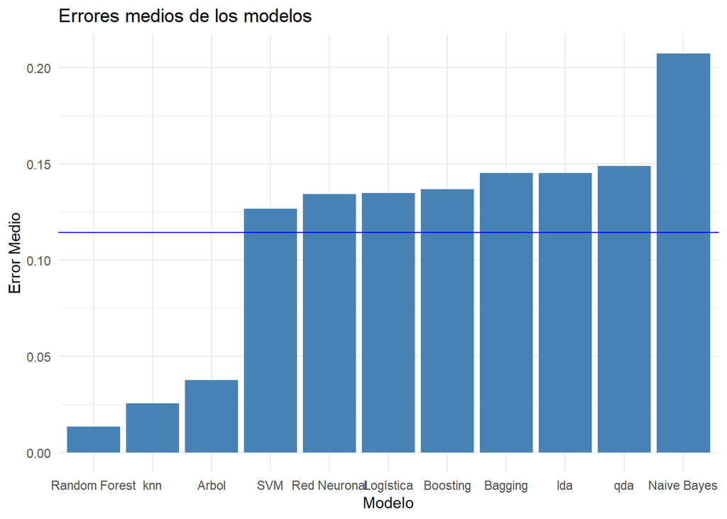

Y además podemos buscar cual es el modelo con menor error:

```r
# mejor modelo
tabla_errores_medios %>% arrange(Error_Medio) %>% slice(1) %>% pull(Modelo)
```

```
## [1] "Random Forest"
```

# 6) Selección del mejor modelo y predicción

Con la tabla de valores de precisión procedente de train/test podemos recoger el mejor modelo, para ello empleamos la columna `Llamada` y la función `get` para convertir ese `chr` en un objeto de modelo.

```r
# prediccion con el mejor modelo
# llamada mejor modelo

best.fit<-tabla_precision %>%
  filter(Train_Test=='Test') %>%
  arrange(desc(Sensibilidad)) %>%
  slice(1) %>% pull(Llamada) %>% get()
```

Después podemos usarlo para predecir nuestras observaciones no definidas:

```r
# prediccion
(nd$X_1 <- predict(best.fit ,nd)$class)
```

```
## [1] "positivo" "positivo" "negativo" "positivo"
```

Pero antes vamos a ver cuales son los tres mejores modelos y sus pronósticos:

```r
# predicciones de los 3 mejores modelos
top3.fit<-tabla_precision %>%
  filter(Train_Test=='Test') %>%
  arrange(desc(Sensibilidad)) %>%
  slice(1:3) %>% pull(Llamada)

top3.fit
```

```
## [1] "boost.fit"  "knn.fit"    "forest.fit"
```

```r
# top 1

predict(get(top3.fit[1]) ,nd)$class
```

```
## [1] "positivo" "positivo" "negativo" "positivo"
```

```r
# top 2

predict(get(top3.fit[2]) ,nd)
```

```
## [1] positivo positivo positivo positivo
## Levels: negativo positivo
```

```r
# top 3

predict(get(top3.fit[3]) ,nd)
```

```
##        1        2        3        4
## positivo positivo negativo positivo
## Levels: negativo positivo
```

# 7) Conclusiones.

- Los procesos de preparación previa a la aplicación de machine learning son vitales para el rendimiento de estas. Si no se estructuran bien los datos y se solucionan problemas de valores ausentes, ciertos algoritmos pueden dar error. Pero si no se retiran outliers y no se equilibran las probabilidades a priori, los algoritmos pierden mucha precisión.
- Elementos como la buena estructura de un proyecto, la eficiencia del código y la reproducibilidad son de suma importancia tanto para el desarrollo del trabajo como para su reutilización en proyectos futuros.
- La muestra parece recoger multitud de datos anómalos.
- En caso de usar variables cualitativas, la variable tipo de trabajo (fijo, temporal, etc.) parece tener gran poder explicativo, pero no podemos descartar que se trate de una correlación espuria pues lo que influye en la solvencia no es el tipo de contrato en sí, sino el ingreso y su periodicidad que van ligados a dicho tipo de contrato.
- Los modelos no paramétricos dan mejores resultados en nuestros datos, esto se debe a su mayor flexibilidad que les permite adaptarse mejor a la naturaleza del problema.

# 8) Errores y omisiones.

- Un análisis clúster más completo podría ayudar a estudiar y comprender mejor los datos.
- Separar en entrenamiento y test tras aplicar las probabilidades a priori no nos permite detectar la pérdida de generalidad que pudieran implicar, por tanto, sería aconsejable separar un conjunto de validación antes de aplicarlas.
- Podríamos mejorar la selección de las variables para incrementar la precisión de los clasificadores.
- Quizás una reducción de la dimensión permitiera mejorar la detección de outliers y la clasificación.
- Hace falta probar todos los escenarios para decidir cual es el mejor método de detección de outliers y para equilibrar las probabilidades a priori.
- Otra cuestión interesante podría ser realizar un análisis de clasificación en los datos de outliers, tanto para clasificar de forma supervisada en posible outlier como para clasificar dichos outliers en negativo o positivo.